# «Стальная птица»

Чтобы оптимизировать производственные расходы, металлургический комбинат «Стальная птица» решил уменьшить потребление электроэнергии на этапе обработки стали. Для этого комбинату нужно контролировать температуру сплава.

Задача — построить модель, которая будет её предсказывать.

Заказчик хочет использовать разработанную модель для имитации технологического процесса.

**Технологический процесс**

Сталь обрабатывают в металлическом ковше вместимостью около 100 тонн. Чтобы ковш выдерживал высокие температуры, изнутри его облицовывают огнеупорным кирпичом. Расплавленную сталь заливают в ковш и подогревают до нужной температуры графитовыми электродами. Они установлены в крышке ковша.

Из сплава выводится сера (этот процесс — десульфурация), добавлением примесей корректируется химический состав и отбираются пробы. Сталь легируют — изменяют её состав — подавая куски сплава из бункера для сыпучих материалов или проволоку через специальный трайб-аппарат (от англ. tribe — «масса»). Перед тем как первый раз ввести легирующие добавки, измеряют температуру стали и производят её химический анализ. Потом температуру на несколько минут повышают, добавляют легирующие материалы и продувают сплав инертным газом. Затем его перемешивают и снова проводят измерения. Такой цикл повторяется до достижения целевого химического состава и оптимальной температуры плавки.

Тогда расплавленная сталь отправляется на доводку металла или поступает в машину непрерывной разливки. Оттуда готовый продукт выходит в виде заготовок-слябов (от англ. slab — «плита»).

**Формулировка задачи машинного обучения**

*Целевой признак - температура розлива:* Необходимо предсказать температуру сплава при розливе. Она важна, так как отражает какое количество электроэнергии потребовалось для обработки разных ковшей.

*Объект предсказания - ковш:* Сталь проходит несколько этапов обработки, однако интересует именно конечный результат, таким образом данные об этапах являются характеристиками целевого признака.

*Примечание о времени:* В рамках данного проекта есть много временных координат, однако основным фактором влияющим на процесс является содержание ковша, которая связана с рядом внешних вакторов, но не определяется временем, поэтому в данном случае использование временных рядов не уместно. Однако, длительность процесса влияет на затраты электроэнергии, как следствие, её стоит учесть.

*Тип задачи:* Так как ЦП - число, здесь имеет место задача регрессии.

*Критерии оценки:* Метрика - MAE. Требования к качеству - MAE $\leq$ 6.8

**План действий**

1. Загрузка. Структура данных.
2. Предобработка, анализ данных и синтез параметров.
3. Объединение данных.
4. Предобработка, анализ объединённых данных.
5. Подготовка данных к МО
6. Обучение моделей.
7. Проверка на контрольной выборке.
8. Заключение. Рекомендации заказчику.

**Содержание**

1. Загрузка. Структура данных.  
   1.1. Этапы
2. Описание, предобработка и анализ.  
   2.1. data_arc_new.csv - данные об электродах : нагрев дугой  
   2.1.1. Анализ  
   2.1.2. Предобработка  
   2.1.3. Синтез параметров  
   2.2. data_bulk_new.csv — данные о подаче сыпучих материалов (объём)  
   2.3. data_bulk_time_new.csv — данные о подаче сыпучих материалов (время);  
   2.4. data_wire_new.csv — данные о проволочных материалах (объём);  
   2.5. data_wire_time_new.csv — данные о проволочных материалах (время);  
   2.6. data_gas_new.csv — данные о продувке сплава газом;  
   2.7. data_temp_new.csv — результаты измерения температуры.  
   2.7.1. Пропуски ЦП  
   2.7.2. Таблица температуры: начало - конец
3. Объединение данных и Анализ объединённого датафрейма.  
   3.1. Объединение  
   3.2. Анализ
4. Машинное обучение.  
   4.1. Подготовка к МО.  
   4.2. Обучение моделей  
   4.2.1. Lin Reg  
   4.2.2. LGBM  
   4.2.3. Forest  
   4.2.4. CatBoost  
   4.3. Оценка моделей  
   4.4. Контрольная выборка  
   4.4.1. Проверка вменяемости  
   4.5. Влияние признаков  
   4.5.1. Shap  
   4.6. Распределение параметров
5. Заключение
6. Отчёт  
   6.1. Ответы на вопросы  
   6.2. Список признаков, используемых для обучения лучшей модели и описание их предобработки.  
   6.3. Гиперпараметры лучшей модели, включая random_state (если имеется у модели).  
   6.4. Что рекомендуете для улучшения модели, решения

*Библиотеки. Параметры. Фиксирование случайности*

```python
import numpy as np
import pandas as pd
import matplotlib.pyplot as plt
import seaborn as sns
import os

# Импортирование библиотек МО в разделе МО
```

```python
plt.rcParams["figure.figsize"] = (7,7)
plt.rc('axes', titlesize='x-large')

pd.set_option('max_rows', 60) # Для сокращённого DataFrame отображения, на случай если установлено высокое значение по умолчанию.
```

```python
RANDOM = 28122023
np.random.seed(RANDOM)
```

## 1. Загрузка. Структура данных.

Данные состоят из нескольких файлов, полученных из разных источников:

```
data_arc_new.csv — данные об электродах;
data_bulk_new.csv — данные о подаче сыпучих материалов (объём);
data_bulk_time_new.csv — данные о подаче сыпучих материалов (время);
data_wire_new.csv — данные о проволочных материалах (объём);
data_wire_time_new.csv — данные о проволочных материалах (время);
data_gas_new.csv — данные о продувке сплава газом;
data_temp_new.csv — результаты измерения температуры.
```

Данные хранятся в нескольких таблицах, формируя сложную структуру близкую к базе данных, сначала загрузим их, чтобы можно было работать с несколькими во время предобработки. Детальная оценка и описание в следующем разделе.

```python
path_local = 'datasets/'
path_platform = '/datasets/'
path_extra = ''

df_list = [
    'data_arc_new.csv',
    'data_bulk_new.csv',
    'data_bulk_time_new.csv',
    'data_wire_new.csv',
    'data_wire_time_new.csv',
    'data_gas_new.csv',
    'data_temp_new.csv'
]

if os.path.exists(path_local) and all(list(map(os.path.exists, map(lambda x: path_local + x, df_list)))):
    df_dir = path_local
    print("Файлы найдены.")
elif os.path.exists(path_platform) and all(list(map(os.path.exists, map(lambda x: path_platform + x, df_list)))):
    df_dir = path_platform
    print("Файлы найдены.")
elif os.path.exists(path_extra) and all(list(map(os.path.exists, map(lambda x: path_extra + x, df_list)))):
    df_dir = path_extra
    print("Файлы найдены.")
elif all(list(map(os.path.exists, df_list))):
    df_dir = ''
    print("Файлы найдены.")
else:
    print("Директория не найдена. Файлы не найдены в текущей.")
```

```
Файлы найдены.
```

```python
arc = pd.read_csv(os.path.join(df_dir, 'data_arc_new.csv'), parse_dates=['Начало нагрева дугой', 'Конец нагрева дугой'])
arc.columns = ['key', 'start', 'end', 'act_pow', 'react_pow']
arc
```

|  | key | start | end | act_pow | react_pow |
| --- | --- | --- | --- | --- | --- |
| 0 | 1 | 2019-05-03 11:02:14 | 2019-05-03 11:06:02 | 0.305130 | 0.211253 |
| 1 | 1 | 2019-05-03 11:07:28 | 2019-05-03 11:10:33 | 0.765658 | 0.477438 |
| 2 | 1 | 2019-05-03 11:11:44 | 2019-05-03 11:14:36 | 0.580313 | 0.430460 |
| 3 | 1 | 2019-05-03 11:18:14 | 2019-05-03 11:24:19 | 0.518496 | 0.379979 |
| 4 | 1 | 2019-05-03 11:26:09 | 2019-05-03 11:28:37 | 0.867133 | 0.643691 |
| ... | ... | ... | ... | ... | ... |
| 14871 | 3241 | 2019-09-06 16:49:05 | 2019-09-06 16:51:42 | 0.439735 | 0.299579 |
| 14872 | 3241 | 2019-09-06 16:55:11 | 2019-09-06 16:58:11 | 0.646498 | 0.458240 |
| 14873 | 3241 | 2019-09-06 17:06:48 | 2019-09-06 17:09:52 | 1.039726 | 0.769302 |
| 14874 | 3241 | 2019-09-06 17:21:58 | 2019-09-06 17:22:55 | 0.530267 | 0.361543 |
| 14875 | 3241 | 2019-09-06 17:24:54 | 2019-09-06 17:26:15 | 0.389057 | 0.251347 |

14876 rows × 5 columns

```python
bulk = pd.read_csv(os.path.join(df_dir, 'data_bulk_new.csv'), index_col='key')
bulk.columns = bulk.columns.str.lower().str.split().str.join('_')
bulk
```

| key | bulk_1 | bulk_2 | bulk_3 | bulk_4 | bulk_5 | bulk_6 | bulk_7 | bulk_8 | bulk_9 | bulk_10 | bulk_11 | bulk_12 | bulk_13 | bulk_14 | bulk_15 |
| --- | --- | --- | --- | --- | --- | --- | --- | --- | --- | --- | --- | --- | --- | --- | --- |
| 1 | NaN | NaN | NaN | 43.0 | NaN | NaN | NaN | NaN | NaN | NaN | NaN | 206.0 | NaN | 150.0 | 154.0 |
| 2 | NaN | NaN | NaN | 73.0 | NaN | NaN | NaN | NaN | NaN | NaN | NaN | 206.0 | NaN | 149.0 | 154.0 |
| 3 | NaN | NaN | NaN | 34.0 | NaN | NaN | NaN | NaN | NaN | NaN | NaN | 205.0 | NaN | 152.0 | 153.0 |
| 4 | NaN | NaN | NaN | 81.0 | NaN | NaN | NaN | NaN | NaN | NaN | NaN | 207.0 | NaN | 153.0 | 154.0 |
| 5 | NaN | NaN | NaN | 78.0 | NaN | NaN | NaN | NaN | NaN | NaN | NaN | 203.0 | NaN | 151.0 | 152.0 |
| ... | ... | ... | ... | ... | ... | ... | ... | ... | ... | ... | ... | ... | ... | ... | ... |
| 3237 | NaN | NaN | 170.0 | NaN | NaN | NaN | NaN | NaN | NaN | NaN | NaN | 252.0 | NaN | 130.0 | 206.0 |
| 3238 | NaN | NaN | 126.0 | NaN | NaN | NaN | NaN | NaN | NaN | NaN | NaN | 254.0 | NaN | 108.0 | 106.0 |
| 3239 | NaN | NaN | NaN | NaN | NaN | 114.0 | NaN | NaN | NaN | NaN | NaN | 158.0 | NaN | 270.0 | 88.0 |
| 3240 | NaN | NaN | NaN | NaN | NaN | 26.0 | NaN | NaN | NaN | NaN | NaN | NaN | NaN | 192.0 | 54.0 |
| 3241 | NaN | NaN | NaN | NaN | NaN | NaN | NaN | NaN | NaN | NaN | NaN | NaN | NaN | 180.0 | 52.0 |

3129 rows × 15 columns

```python
bulk_time = pd.read_csv(os.path.join(df_dir, 'data_bulk_time_new.csv'), parse_dates=['Bulk ' + str(x) for x in range(1, 16)], index_col='key')
bulk_time.columns = bulk_time.columns.str.lower().str.split().str.join('_')
bulk_time
```

| key | bulk_1 | bulk_2 | bulk_3 | bulk_4 | bulk_5 | bulk_6 | bulk_7 | bulk_8 | bulk_9 | bulk_10 | bulk_11 | bulk_12 | bulk_13 | bulk_14 | bulk_15 |
| --- | --- | --- | --- | --- | --- | --- | --- | --- | --- | --- | --- | --- | --- | --- | --- |
| 1 | NaT | NaT | NaT | 2019-05-03 11:28:48 | NaT | NaT | NaT | NaT | NaT | NaT | NaT | 2019-05-03 11:24:31 | NaT | 2019-05-03 11:14:50 | 2019-05-03 11:10:43 |
| 2 | NaT | NaT | NaT | 2019-05-03 11:36:50 | NaT | NaT | NaT | NaT | NaT | NaT | NaT | 2019-05-03 11:53:30 | NaT | 2019-05-03 11:48:37 | 2019-05-03 11:44:39 |
| 3 | NaT | NaT | NaT | 2019-05-03 12:32:39 | NaT | NaT | NaT | NaT | NaT | NaT | NaT | 2019-05-03 12:27:13 | NaT | 2019-05-03 12:21:01 | 2019-05-03 12:16:16 |
| 4 | NaT | NaT | NaT | 2019-05-03 12:43:22 | NaT | NaT | NaT | NaT | NaT | NaT | NaT | 2019-05-03 12:58:00 | NaT | 2019-05-03 12:51:11 | 2019-05-03 12:46:36 |
| 5 | NaT | NaT | NaT | 2019-05-03 13:30:47 | NaT | NaT | NaT | NaT | NaT | NaT | NaT | 2019-05-03 13:30:47 | NaT | 2019-05-03 13:34:12 | 2019-05-03 13:30:47 |
| ... | ... | ... | ... | ... | ... | ... | ... | ... | ... | ... | ... | ... | ... | ... | ... |
| 3237 | NaT | NaT | 2019-09-06 11:54:15 | NaT | NaT | NaT | NaT | NaT | NaT | NaT | NaT | 2019-09-06 11:49:45 | NaT | 2019-09-06 11:45:22 | 2019-09-06 11:40:06 |
| 3238 | NaT | NaT | 2019-09-06 12:26:52 | NaT | NaT | NaT | NaT | NaT | NaT | NaT | NaT | 2019-09-06 12:18:35 | NaT | 2019-09-06 12:31:49 | 2019-09-06 12:26:52 |
| 3239 | NaT | NaT | NaT | NaT | NaT | 2019-09-06 15:06:00 | NaT | NaT | NaT | NaT | NaT | 2019-09-06 15:01:44 | NaT | 2019-09-06 14:58:15 | 2019-09-06 14:48:06 |
| 3240 | NaT | NaT | NaT | NaT | NaT | 2019-09-06 16:24:28 | NaT | NaT | NaT | NaT | NaT | NaT | NaT | 2019-09-06 16:07:29 | 2019-09-06 16:01:34 |
| 3241 | NaT | NaT | NaT | NaT | NaT | NaT | NaT | NaT | NaT | NaT | NaT | NaT | NaT | 2019-09-06 17:26:33 | 2019-09-06 17:23:15 |

3129 rows × 15 columns

```python
wire = pd.read_csv(os.path.join(df_dir, 'data_wire_new.csv'), index_col='key')
wire.columns = wire.columns.str.lower().str.split().str.join('_')
wire
```

| key | wire_1 | wire_2 | wire_3 | wire_4 | wire_5 | wire_6 | wire_7 | wire_8 | wire_9 |
| --- | --- | --- | --- | --- | --- | --- | --- | --- | --- |
| 1 | 60.059998 | NaN | NaN | NaN | NaN | NaN | NaN | NaN | NaN |
| 2 | 96.052315 | NaN | NaN | NaN | NaN | NaN | NaN | NaN | NaN |
| 3 | 91.160157 | NaN | NaN | NaN | NaN | NaN | NaN | NaN | NaN |
| 4 | 89.063515 | NaN | NaN | NaN | NaN | NaN | NaN | NaN | NaN |
| 5 | 89.238236 | 9.11456 | NaN | NaN | NaN | NaN | NaN | NaN | NaN |
| ... | ... | ... | ... | ... | ... | ... | ... | ... | ... |
| 3237 | 38.088959 | NaN | NaN | NaN | NaN | NaN | NaN | NaN | NaN |
| 3238 | 56.128799 | NaN | NaN | NaN | NaN | NaN | NaN | NaN | NaN |
| 3239 | 143.357761 | NaN | NaN | NaN | NaN | NaN | NaN | NaN | NaN |
| 3240 | 34.070400 | NaN | NaN | NaN | NaN | NaN | NaN | NaN | NaN |
| 3241 | 63.117595 | NaN | NaN | NaN | NaN | NaN | NaN | NaN | NaN |

3081 rows × 9 columns

```python
wire_time = pd.read_csv(os.path.join(df_dir, 'data_wire_time_new.csv'), parse_dates=['Wire ' + str(x) for x in range(1, 10)], index_col='key')
wire_time.columns = wire_time.columns.str.lower().str.split().str.join('_')
wire_time
```

| key | wire_1 | wire_2 | wire_3 | wire_4 | wire_5 | wire_6 | wire_7 | wire_8 | wire_9 |
| --- | --- | --- | --- | --- | --- | --- | --- | --- | --- |
| 1 | 2019-05-03 11:06:19 | NaT | NaT | NaT | NaT | NaT | NaT | NaT | NaT |
| 2 | 2019-05-03 11:36:50 | NaT | NaT | NaT | NaT | NaT | NaT | NaT | NaT |
| 3 | 2019-05-03 12:11:46 | NaT | NaT | NaT | NaT | NaT | NaT | NaT | NaT |
| 4 | 2019-05-03 12:43:22 | NaT | NaT | NaT | NaT | NaT | NaT | NaT | NaT |
| 5 | 2019-05-03 13:20:44 | 2019-05-03 13:15:34 | NaT | NaT | NaT | NaT | NaT | NaT | NaT |
| ... | ... | ... | ... | ... | ... | ... | ... | ... | ... |
| 3237 | 2019-09-06 11:33:38 | NaT | NaT | NaT | NaT | NaT | NaT | NaT | NaT |
| 3238 | 2019-09-06 12:18:35 | NaT | NaT | NaT | NaT | NaT | NaT | NaT | NaT |
| 3239 | 2019-09-06 14:36:11 | NaT | NaT | NaT | NaT | NaT | NaT | NaT | NaT |
| 3240 | 2019-09-06 15:33:55 | NaT | NaT | NaT | NaT | NaT | NaT | NaT | NaT |
| 3241 | 2019-09-06 17:10:06 | NaT | NaT | NaT | NaT | NaT | NaT | NaT | NaT |

3081 rows × 9 columns

```python
gas = pd.read_csv(os.path.join(df_dir, 'data_gas_new.csv'), index_col='key')
gas.columns = ['gas_1']
gas
```

| key | gas_1 |
| --- | --- |
| 1 | 29.749986 |
| 2 | 12.555561 |
| 3 | 28.554793 |
| 4 | 18.841219 |
| 5 | 5.413692 |
| ... | ... |
| 3237 | 5.543905 |
| 3238 | 6.745669 |
| 3239 | 16.023518 |
| 3240 | 11.863103 |
| 3241 | 12.680959 |

3239 rows × 1 columns

```python
temp = pd.read_csv(os.path.join(df_dir, 'data_temp_new.csv'), parse_dates=['Время замера']) # temp - temperature
temp.columns = ['key', 'time', 'temp']
temp
```

|  | key | time | temp |
| --- | --- | --- | --- |
| 0 | 1 | 2019-05-03 11:02:04 | 1571.0 |
| 1 | 1 | 2019-05-03 11:07:18 | 1604.0 |
| 2 | 1 | 2019-05-03 11:11:34 | 1618.0 |
| 3 | 1 | 2019-05-03 11:18:04 | 1601.0 |
| 4 | 1 | 2019-05-03 11:25:59 | 1606.0 |
| ... | ... | ... | ... |
| 18087 | 3241 | 2019-09-06 16:55:01 | NaN |
| 18088 | 3241 | 2019-09-06 17:06:38 | NaN |
| 18089 | 3241 | 2019-09-06 17:21:48 | NaN |
| 18090 | 3241 | 2019-09-06 17:24:44 | NaN |
| 18091 | 3241 | 2019-09-06 17:30:05 | NaN |

18092 rows × 3 columns

### 1.1. Этапы

```python
pd.DataFrame(arc.key.value_counts().value_counts().sort_index()).rename(columns={'key':'count_of_stages_for_key'}).transpose()
```

|  | 1 | 2 | 3 | 4 | 5 | 6 | 7 | 8 | 9 | 10 | 11 | 12 | 13 | 14 | 15 | 16 |
| --- | --- | --- | --- | --- | --- | --- | --- | --- | --- | --- | --- | --- | --- | --- | --- | --- |
| count_of_stages_for_key | 39 | 174 | 520 | 892 | 759 | 490 | 205 | 84 | 28 | 9 | 5 | 3 | 2 | 1 | 2 | 1 |

```python
pd.DataFrame(temp.key.value_counts().value_counts().sort_index()).rename(columns={'key':'count_of_stages_for_key'}).transpose()
```

|  | 1 | 2 | 3 | 4 | 5 | 6 | 7 | 8 | 9 | 10 | 11 | 12 | 13 | 14 | 15 | 16 | 17 |
| --- | --- | --- | --- | --- | --- | --- | --- | --- | --- | --- | --- | --- | --- | --- | --- | --- | --- |
| count_of_stages_for_key | 2 | 39 | 174 | 520 | 892 | 759 | 490 | 205 | 84 | 28 | 9 | 5 | 3 | 2 | 1 | 2 | 1 |

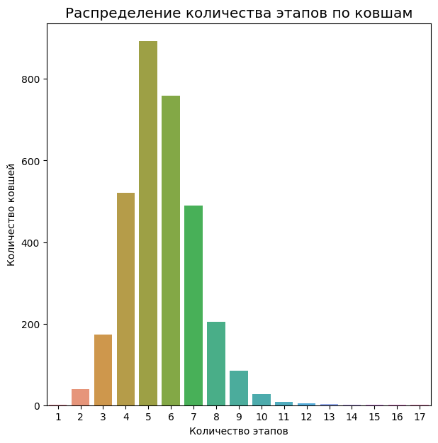

```python
sns.barplot(x=list(range(1,18)), y=temp.key.value_counts().value_counts().sort_index());
plt.title('Распределение количества этапов по ковшам')
plt.xlabel('Количество этапов')
plt.ylabel('Количество ковшей')
plt.show()
```

```python
arc.query('key==1')
```

|  | key | start | end | act_pow | react_pow |
| --- | --- | --- | --- | --- | --- |
| 0 | 1 | 2019-05-03 11:02:14 | 2019-05-03 11:06:02 | 0.305130 | 0.211253 |
| 1 | 1 | 2019-05-03 11:07:28 | 2019-05-03 11:10:33 | 0.765658 | 0.477438 |
| 2 | 1 | 2019-05-03 11:11:44 | 2019-05-03 11:14:36 | 0.580313 | 0.430460 |
| 3 | 1 | 2019-05-03 11:18:14 | 2019-05-03 11:24:19 | 0.518496 | 0.379979 |
| 4 | 1 | 2019-05-03 11:26:09 | 2019-05-03 11:28:37 | 0.867133 | 0.643691 |

```python
temp.query('key==1')
```

|  | key | time | temp |
| --- | --- | --- | --- |
| 0 | 1 | 2019-05-03 11:02:04 | 1571.0 |
| 1 | 1 | 2019-05-03 11:07:18 | 1604.0 |
| 2 | 1 | 2019-05-03 11:11:34 | 1618.0 |
| 3 | 1 | 2019-05-03 11:18:04 | 1601.0 |
| 4 | 1 | 2019-05-03 11:25:59 | 1606.0 |
| 5 | 1 | 2019-05-03 11:30:38 | 1613.0 |

Можно увидеть, что для каждого ковша может быть разное количество этапов, которое распределено нормально с правым хвостом, что говорит о том, что некоторые ковши требуют значительно большей обработки чем большинство. Кроме того, в таблице температур содержится дополнительная строка - температура розлива - целевой признак, примечательно, что судя по тому что `temp` содержит время начала этапа, температура измеряется в начале этапа.

Стоит отметить что есть 2 ковша в которых есть только одно значение температуры, возможно их состав был удовлетворителен после начального нагрева и поэтому дальнейшая обработка не потребовалась. Детальнее рассмотрены будут в следующем разделе.

**Выводы**

Данные загружены, название колонок приведены к `snake_case`. Даны парсированы. `key` используем как индекс, за исключением `arc` и `temp`, где может быть несколько этапов одной партии.

Говоря о данных в целом таблицы имеет смысл разделить на 4 категории:

- `arc` описывает мощности при нагреве на каждом этапе каждого ковша
- `bulk`, `wire`, `gas` описывают добавки к сплаву для приведения его к необходимому состоянию для отлива
- `bulk_time`, `wire_time` предоставляют информацию о времени добавления добавок, что даёт понять на каком этапе процесса были сделаны добавки. Здесь примечательны несколько вещей. Во первых, нет времени добавки газа, значит либо газ добавляется на нескольких этапах вместе с добавками, либо данных об этом этапе нет и в случае необходимости придётся определять этап(ы) добавления газа по остаточному признаку. Во вторых, само время добавки, представляет низкий интерес, также, на первый взгляд, довольно малое значение несёт детальная оценка этапов - цель заказчика определить финальное состояние (температуру) продукта на основе данных о ковше, однако не обязательно, что детальная оценка и моделирование каждого этапа даст лучший результат, поскольку ценность МО в поиске общих закономерностей, а излишняя детализация может привести к переобучению.
- `temp`содержит информацию о температуре на разных этапах, в частности интересует температура на последнем этапе - в момент розлива - которая является целевым признаком.

Общая структура данных подсказывает два возможных подхода к созданию признаков - первый собрать данные о всех этапах, включая добавки и температуру, чтобы смоделировать каждый этап, второй, попытаться сгруппировать информацию для каждого ковша не придавая значения каждому отдельному этапу.

Проблема первого подхода, помимо его более высокой сложности в реализации, в том что алгоритмам МО может быть сложно научиться оценивать тот или иной ковш, учитывая что количество этапов не постоянно.

Проблема второго подхода в том что он не моделирует, в полной мере, производственный процесс, вместо этого оценивая его "в общем", однако это может дать лучшие показатели в МО, т.к. делает проще поиск закономерностей.

## 2. Описание, предобработка и анализ.

Стоит заметить, что в рамках анализа ключ, ковш, и партия - синонимы. Здесь они описывают объект исследования - разогретый сплав металлов поданный в ковш на производстве. В данных информация об этом содержится в колонках `key`, в случае с таблицами где ключ встречается только один раз, он вынесен в индекс.

### 2.1. data_arc_new.csv - данные об электродах : нагрев дугой

#### 2.1.1. Анализ

```
key — номер партии;
Начало нагрева дугой — время начала нагрева;
Конец нагрева дугой — время окончания нагрева;
Активная мощность — значение активной мощности;
Реактивная мощность — значение реактивной мощности.
```

Всего около 15 тысяч записей, 5 колонок, `key` - по сути номер ковша, с точки зрения базы данных - вместе со временем формирует первичный ключ, и, также, служит как внешний ключ для связи с другими таблицами.

Время нагрева интересует с точки зрения длительности процесса, и как следствие затрат энергии.

Активная и реактивная мощности не дают полную информацию о затраченной мощности, требуется вывести полную мощность.

Возможно, работа как функция этих величин даст лучшие результаты в МО.

#### 2.1.2. Предобработка

```python
arc.info()
```

```
<class 'pandas.core.frame.DataFrame'>
RangeIndex: 14876 entries, 0 to 14875
Data columns (total 5 columns):
 #   Column     Non-Null Count  Dtype
---  ------     --------------  -----
 0   key        14876 non-null  int64
 1   start      14876 non-null  datetime64[ns]
 2   end        14876 non-null  datetime64[ns]
 3   act_pow    14876 non-null  float64
 4   react_pow  14876 non-null  float64
dtypes: datetime64[ns](2), float64(2), int64(1)
memory usage: 581.2 KB
```

```python
arc.isna().sum()
```

```
key          0
start        0
end          0
act_pow      0
react_pow    0
dtype: int64
```

Пропусков нет.

```python
arc.duplicated().sum()
```

```
0
```

Дубликатов нет.

```python
arc.key.unique().shape
```

```
(3214,)
```

```python
arc.key.max()
```

```
3241
```

Всего партий 3214. При этом в таблице номер последней партии 3241, Значит данных о некоторых партиях в таблице нет.

```python
arc.drop('key', axis=1).describe(include='all', datetime_is_numeric=True)
```

|  | start | end | act_pow | react_pow |
| --- | --- | --- | --- | --- |
| count | 14876 | 14876 | 14876.000000 | 14876.000000 |
| mean | 2019-07-05 12:25:51.921081088 | 2019-07-05 12:28:43.592027392 | 0.662752 | 0.438986 |
| min | 2019-05-03 11:02:14 | 2019-05-03 11:06:02 | 0.223120 | -715.479924 |
| 25% | 2019-06-03 23:18:23.249999872 | 2019-06-03 23:21:35 | 0.467115 | 0.337175 |
| 50% | 2019-07-03 01:31:26.500000 | 2019-07-03 01:35:13 | 0.599587 | 0.441639 |
| 75% | 2019-08-07 22:52:20.750000128 | 2019-08-07 22:56:47 | 0.830070 | 0.608201 |
| max | 2019-09-06 17:24:54 | 2019-09-06 17:26:15 | 1.463773 | 1.270284 |
| std | NaN | NaN | 0.258885 | 5.873485 |

Отрицательная реактивная мощность возможна, но -715 это аномалия по размеру.

```python
arc.loc[arc.key.isin(arc.key[arc.react_pow <= 0])]
```

|  | key | start | end | act_pow | react_pow |
| --- | --- | --- | --- | --- | --- |
| 9778 | 2116 | 2019-07-28 02:07:12 | 2019-07-28 02:09:14 | 0.787549 | 0.693881 |
| 9779 | 2116 | 2019-07-28 02:13:10 | 2019-07-28 02:15:25 | 0.580263 | 0.411498 |
| 9780 | 2116 | 2019-07-28 02:22:08 | 2019-07-28 02:23:57 | 0.705344 | -715.479924 |
| 9781 | 2116 | 2019-07-28 02:29:11 | 2019-07-28 02:30:18 | 0.563641 | 0.408513 |

Отрицательная реактивная мощность только у одного этапа одного ковша.

```python
arc.loc[9780, 'react_pow'] = arc.act_pow[9780]*(arc.react_pow.drop(9780)/arc.act_pow.drop(9780)).mean()
```

Заменил аномалию реактивной мощности средним значением в отношении активной.

```python
arc.loc[arc.key == 2116]
```

|  | key | start | end | act_pow | react_pow |
| --- | --- | --- | --- | --- | --- |
| 9778 | 2116 | 2019-07-28 02:07:12 | 2019-07-28 02:09:14 | 0.787549 | 0.693881 |
| 9779 | 2116 | 2019-07-28 02:13:10 | 2019-07-28 02:15:25 | 0.580263 | 0.411498 |
| 9780 | 2116 | 2019-07-28 02:22:08 | 2019-07-28 02:23:57 | 0.705344 | 0.518374 |
| 9781 | 2116 | 2019-07-28 02:29:11 | 2019-07-28 02:30:18 | 0.563641 | 0.408513 |

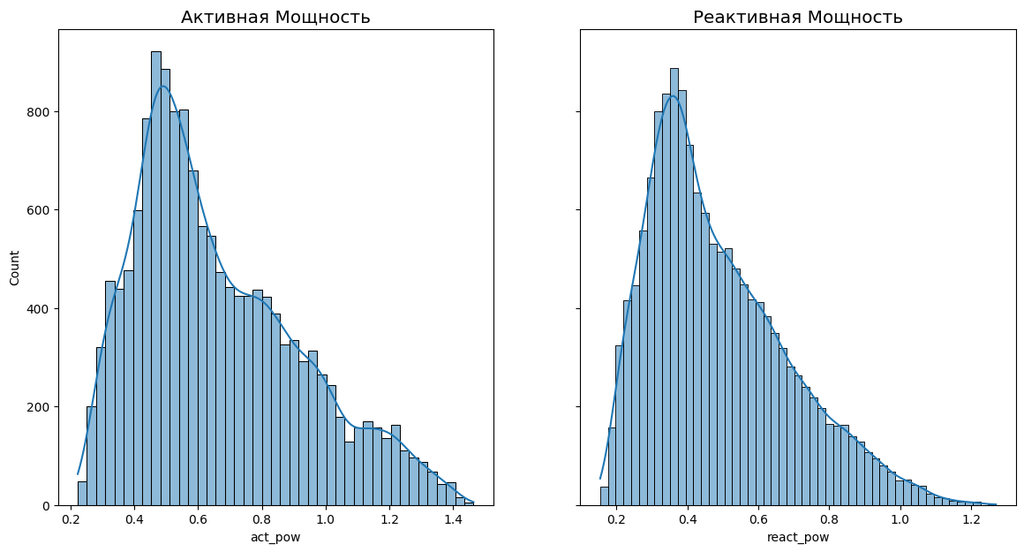

```python
fig, axs = plt.subplots(1,2, figsize=(14,7), sharey=True)

plt.sca(axs[0])
sns.histplot(arc.act_pow, kde=True)
plt.title('Активная Мощность')

plt.sca(axs[1])
sns.histplot(arc.react_pow, kde=True)
plt.title('Реактивная Мощность');
```

Активная и реактивная мощности распределены близко к нормальному, реактивная более гладкая. Реактивная мощность ниже активной, но довольно высокая, что, в целом соответствует ожиданиям технологического процесса. Явных аномалий не наблюдается.

```python
arc[arc.start > arc.end]
```

|  | key | start | end | act_pow | react_pow |
| --- | --- | --- | --- | --- | --- |

```python
arc[arc.start < arc.start.shift()]
```

|  | key | start | end | act_pow | react_pow |
| --- | --- | --- | --- | --- | --- |

```python
arc[arc.end < arc.end.shift()]
```

|  | key | start | end | act_pow | react_pow |
| --- | --- | --- | --- | --- | --- |

Время проходит оценку на вменяемость - начало по времени до конца, все стадии следуют друг за другом по времени.

```python
(arc.end - arc.start).describe()
```

```
count                        14876
mean     0 days 00:02:51.670946490
std      0 days 00:01:38.186802680
min                0 days 00:00:11
25%                0 days 00:01:47
50%                0 days 00:02:27
75%                0 days 00:03:34
max                0 days 00:15:07
dtype: object
```

Длинна этапа имеет максимум значительно выше q3 (75%) рассмотрим.

```python
arc[(arc.end - arc.start) > '00:05:00']
```

|  | key | start | end | act_pow | react_pow |
| --- | --- | --- | --- | --- | --- |
| 3 | 1 | 2019-05-03 11:18:14 | 2019-05-03 11:24:19 | 0.518496 | 0.379979 |
| 6 | 2 | 2019-05-03 11:38:50 | 2019-05-03 11:44:28 | 0.261665 | 0.205527 |
| 20 | 5 | 2019-05-03 13:23:32 | 2019-05-03 13:30:27 | 0.461620 | 0.308665 |
| 23 | 6 | 2019-05-03 13:50:39 | 2019-05-03 13:57:17 | 0.847190 | 0.562753 |
| 27 | 7 | 2019-05-03 14:21:06 | 2019-05-03 14:27:03 | 0.854873 | 0.639473 |
| ... | ... | ... | ... | ... | ... |
| 14794 | 3223 | 2019-09-06 01:43:36 | 2019-09-06 01:50:17 | 0.718639 | 0.566517 |
| 14804 | 3225 | 2019-09-06 03:42:55 | 2019-09-06 03:48:57 | 0.427297 | 0.305152 |
| 14824 | 3229 | 2019-09-06 07:01:11 | 2019-09-06 07:06:24 | 1.352936 | 0.923058 |
| 14826 | 3230 | 2019-09-06 07:30:16 | 2019-09-06 07:35:25 | 0.285663 | 0.209137 |
| 14827 | 3230 | 2019-09-06 07:37:38 | 2019-09-06 07:42:46 | 0.526767 | 0.411200 |

1546 rows × 5 columns

Около 10% записей дольше 5 минут. Записи принадлежат разным партиям, возможно один из этапов процесса занимает более длительное время чем другие. В целом не вызывает сомнений в качестве данных.

```python
arc_long_check = pd.concat(
    [arc.drop('key', axis=1).describe(),
     arc.drop('key', axis=1)[(arc.end - arc.start) > '00:05:00'].describe(),
     arc.drop('key', axis=1)[(arc.end - arc.start) > '00:07:00'].describe(),
     arc.drop('key', axis=1)[(arc.end - arc.start) > '00:010:00'].describe()],
     axis=1, keys=['all', '5_min', '7_min', '10_min']
)

arc_long_check.loc['count', :].drop_duplicates().droplevel(1).astype('int')
```

```
all       14876
5_min      1546
7_min       401
10_min       61
Name: count, dtype: int32
```

Этапов дольше 7 минут только около 3% от данных, 10 меньше одного, в целом правдоподобные выбросы.

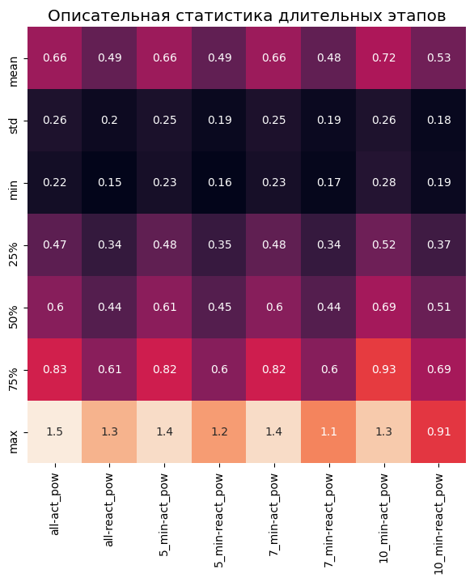

```python
sns.heatmap(arc_long_check.drop('count'), annot=True, cbar=False).set(xlabel='')
plt.title('Описательная статистика длительных этапов');
```

Значения мощностей не сильно отличаются, кроме наиболее длительных этапов, где виден значимый прирост затрат, однако он является частью полезной информации о производстве, поэтому отбрасывать не уместно.

#### 2.1.3. Синтез параметров

$ Полная \ мощность = \sqrt{(Активная \ мощность ^ 2 + Реактивная \ мощность ^ 2)} $

```python
arc['apparent_pow'] = (arc.act_pow ** 2 + arc.react_pow ** 2) ** .5
arc
```

|  | key | start | end | act_pow | react_pow | apparent_pow |
| --- | --- | --- | --- | --- | --- | --- |
| 0 | 1 | 2019-05-03 11:02:14 | 2019-05-03 11:06:02 | 0.305130 | 0.211253 | 0.371123 |
| 1 | 1 | 2019-05-03 11:07:28 | 2019-05-03 11:10:33 | 0.765658 | 0.477438 | 0.902319 |
| 2 | 1 | 2019-05-03 11:11:44 | 2019-05-03 11:14:36 | 0.580313 | 0.430460 | 0.722536 |
| 3 | 1 | 2019-05-03 11:18:14 | 2019-05-03 11:24:19 | 0.518496 | 0.379979 | 0.642824 |
| 4 | 1 | 2019-05-03 11:26:09 | 2019-05-03 11:28:37 | 0.867133 | 0.643691 | 1.079934 |
| ... | ... | ... | ... | ... | ... | ... |
| 14871 | 3241 | 2019-09-06 16:49:05 | 2019-09-06 16:51:42 | 0.439735 | 0.299579 | 0.532085 |
| 14872 | 3241 | 2019-09-06 16:55:11 | 2019-09-06 16:58:11 | 0.646498 | 0.458240 | 0.792429 |
| 14873 | 3241 | 2019-09-06 17:06:48 | 2019-09-06 17:09:52 | 1.039726 | 0.769302 | 1.293389 |
| 14874 | 3241 | 2019-09-06 17:21:58 | 2019-09-06 17:22:55 | 0.530267 | 0.361543 | 0.641792 |
| 14875 | 3241 | 2019-09-06 17:24:54 | 2019-09-06 17:26:15 | 0.389057 | 0.251347 | 0.463185 |

14876 rows × 6 columns

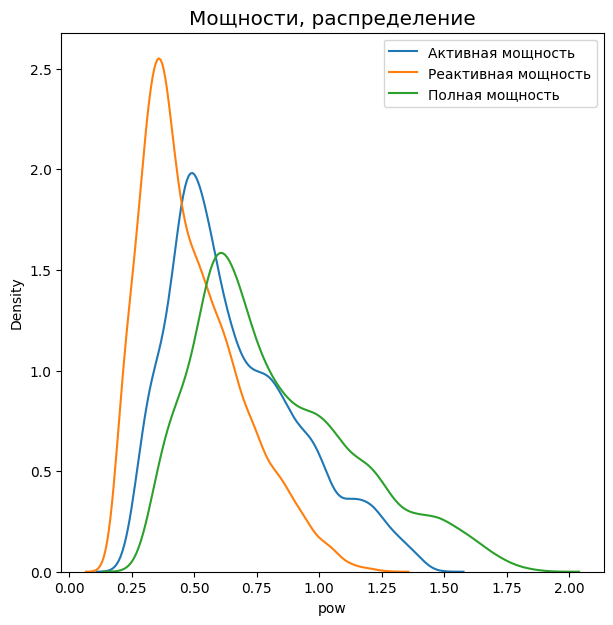

```python
plt.figure()

sns.kdeplot(arc.act_pow)
sns.kdeplot(arc.react_pow)
sns.kdeplot(arc.apparent_pow)

plt.title('Мощности, распределение')
plt.legend(['Активная мощность', 'Реактивная мощность', 'Полная мощность'])
plt.xlabel('pow')
plt.show()
```

Полная мощность, ожидаемо, больше активной и реактивной, и имеет более выраженный и менее гладкий правый хвост, что говорит о том что затраты электроэнергии на этапы с высокой полной мощностью значительно растут.

$ Время \ этапов $

```python
arc['duration'] = (arc.end - arc.start).dt.seconds
arc['duration']
```

```
0        228
1        185
2        172
3        365
4        148
        ...
14871    157
14872    180
14873    184
14874     57
14875     81
Name: duration, Length: 14876, dtype: int64
```

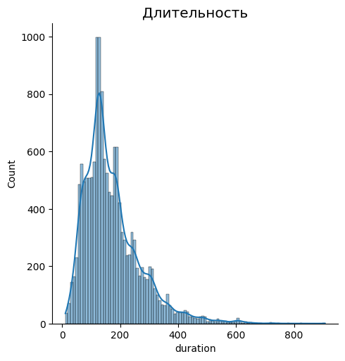

```python
sns.displot(arc.duration, kde=True);
plt.title("Длительность")
plt.show()
```

Распределение длительности близко к нормальному но имеются скачки - локальные максимумы - которое делают его несколько ступенчатым. Возможно определённые этапы занимают близкие по длительности промежутки времени, и это создаёт такой эффект.

$ Работа $

```python
arc['work'] = arc.duration * arc.apparent_pow
arc['work']
```

```
0         84.616003
1        166.928978
2        124.276277
3        234.630603
4        159.830252
            ...
14871     83.537345
14872    142.637202
14873    237.983620
14874     36.582120
14875     37.518013
Name: work, Length: 14876, dtype: float64
```

```python
arc.work.describe()
```

```
count    14876.000000
mean       141.643891
std        103.197604
min          6.409531
25%         71.158372
50%        114.462623
75%        181.345716
max       1084.729420
Name: work, dtype: float64
```

```python
arc.query('work < 15')
```

|  | key | start | end | act_pow | react_pow | apparent_pow | duration | work |
| --- | --- | --- | --- | --- | --- | --- | --- | --- |
| 508 | 110 | 2019-05-07 11:58:29 | 2019-05-07 11:58:47 | 0.293605 | 0.207924 | 0.359773 | 18 | 6.475906 |
| 676 | 146 | 2019-05-09 04:20:55 | 2019-05-09 04:21:07 | 0.798714 | 0.542755 | 0.965674 | 12 | 11.588093 |
| 769 | 164 | 2019-05-09 22:00:05 | 2019-05-09 22:00:32 | 0.394162 | 0.287730 | 0.488008 | 27 | 13.176228 |
| 1026 | 222 | 2019-05-11 23:59:14 | 2019-05-11 23:59:45 | 0.328106 | 0.314192 | 0.454280 | 31 | 14.082675 |
| 1069 | 231 | 2019-05-12 10:35:27 | 2019-05-12 10:35:56 | 0.334976 | 0.230646 | 0.406702 | 29 | 11.794357 |
| ... | ... | ... | ... | ... | ... | ... | ... | ... |
| 13745 | 2981 | 2019-08-28 17:56:20 | 2019-08-28 17:56:34 | 0.445312 | 0.278084 | 0.525008 | 14 | 7.350113 |
| 14304 | 3111 | 2019-09-02 02:58:09 | 2019-09-02 02:58:36 | 0.285068 | 0.181874 | 0.338145 | 27 | 9.129910 |
| 14350 | 3120 | 2019-09-02 14:11:47 | 2019-09-02 14:12:03 | 0.735823 | 0.505123 | 0.892516 | 16 | 14.280255 |
| 14443 | 3141 | 2019-09-03 04:45:57 | 2019-09-03 04:46:21 | 0.456143 | 0.298556 | 0.545162 | 24 | 13.083899 |
| 14586 | 3173 | 2019-09-04 07:20:35 | 2019-09-04 07:21:03 | 0.291379 | 0.208337 | 0.358198 | 28 | 10.029553 |

65 rows × 8 columns

Довольно низкий минимум и максимум, но учитывая, что мощность меньше единицы, правдоподобный для этапов длинной 10-20 секунд.

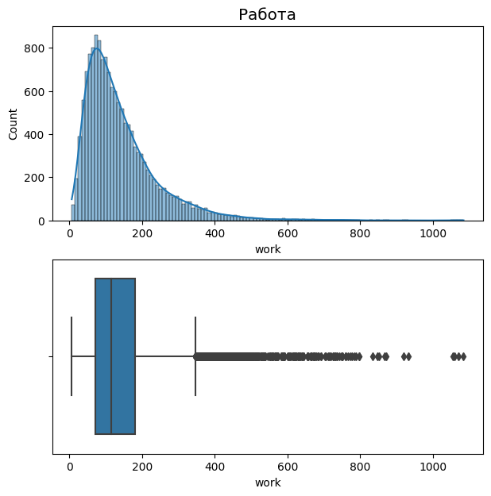

```python
plt.subplot(211)
sns.histplot(arc.work, kde=True)
plt.title('Работа')
plt.subplot(212)
sns.boxplot(x=arc.work)
plt.show()
```

Работа имеет наиболее гладкое нормальное распределение, по сравнению с другими признаками, что делает её очень хорошим кандидатом для использования в качестве признака в МО. Рассмотрим выбросы.

```python
suspect_keys_arc = arc[arc.work > 1000].key
arc[arc.work > 1000]
```

|  | key | start | end | act_pow | react_pow | apparent_pow | duration | work |
| --- | --- | --- | --- | --- | --- | --- | --- | --- |
| 2027 | 437 | 2019-05-20 02:40:51 | 2019-05-20 02:52:03 | 1.317476 | 0.856872 | 1.571615 | 672 | 1056.125051 |
| 7799 | 1689 | 2019-07-05 11:30:50 | 2019-07-05 11:45:57 | 0.966775 | 0.675200 | 1.179215 | 907 | 1069.548361 |
| 12424 | 2701 | 2019-08-18 00:40:31 | 2019-08-18 00:54:17 | 1.027288 | 0.769083 | 1.283281 | 826 | 1059.989839 |
| 13760 | 2985 | 2019-08-28 21:57:30 | 2019-08-28 22:08:37 | 1.346628 | 0.911802 | 1.626281 | 667 | 1084.729420 |

```python
arc.duration.describe()
```

```
count    14876.000000
mean       171.670946
std         98.186803
min         11.000000
25%        107.000000
50%        147.000000
75%        214.000000
max        907.000000
Name: duration, dtype: float64
```

```python
temp[temp.key.isin(suspect_keys_arc)]
```

|  | key | time | temp |
| --- | --- | --- | --- |
| 2458 | 437 | 2019-05-20 02:35:40 | 1600.0 |
| 2459 | 437 | 2019-05-20 02:40:41 | 1592.0 |
| 2460 | 437 | 2019-05-20 03:12:15 | 1617.0 |
| 2461 | 437 | 2019-05-20 03:27:48 | 1618.0 |
| 2462 | 437 | 2019-05-20 03:36:33 | 1610.0 |
| 2463 | 437 | 2019-05-20 03:47:08 | 1618.0 |
| 9467 | 1689 | 2019-07-05 08:07:11 | 1583.0 |
| 9468 | 1689 | 2019-07-05 08:11:56 | 1591.0 |
| 9469 | 1689 | 2019-07-05 08:20:43 | 1597.0 |
| 9470 | 1689 | 2019-07-05 08:32:41 | 1600.0 |
| 9471 | 1689 | 2019-07-05 08:40:50 | 1602.0 |
| 9472 | 1689 | 2019-07-05 11:22:57 | 1608.0 |
| 9473 | 1689 | 2019-07-05 11:30:40 | 1526.0 |
| 9474 | 1689 | 2019-07-05 12:39:10 | 1559.0 |
| 9475 | 1689 | 2019-07-05 12:51:31 | 1575.0 |
| 9476 | 1689 | 2019-07-05 14:05:04 | 1626.0 |
| 9477 | 1689 | 2019-07-05 14:08:11 | 1587.0 |
| 9478 | 1689 | 2019-07-05 14:11:04 | 1604.0 |
| 9479 | 1689 | 2019-07-05 14:19:14 | 1600.0 |
| 9480 | 1689 | 2019-07-05 14:30:19 | 1603.0 |
| 9481 | 1689 | 2019-07-05 14:36:49 | 1589.0 |
| 9482 | 1689 | 2019-07-05 14:41:45 | 1606.0 |
| 15100 | 2701 | 2019-08-18 00:36:38 | 1571.0 |
| 15101 | 2701 | 2019-08-18 00:40:21 | NaN |
| 15102 | 2701 | 2019-08-18 01:01:46 | NaN |
| 15103 | 2701 | 2019-08-18 01:07:17 | NaN |
| 15104 | 2701 | 2019-08-18 01:11:55 | NaN |
| 16720 | 2985 | 2019-08-28 21:51:50 | 1588.0 |
| 16721 | 2985 | 2019-08-28 21:57:20 | NaN |
| 16722 | 2985 | 2019-08-28 22:13:17 | NaN |
| 16723 | 2985 | 2019-08-28 22:20:43 | NaN |
| 16724 | 2985 | 2019-08-28 22:28:18 | NaN |
| 16725 | 2985 | 2019-08-28 22:34:03 | NaN |

Первые два высоких значения оправданы скачком температур в 30 градусов, последние лва не имеют информации о температуре. Создадим список с отбрасываемыми ключами содержащий их.

```python
discard_keys = [2701, 2985]
```

```python
arc
```

|  | key | start | end | act_pow | react_pow | apparent_pow | duration | work |
| --- | --- | --- | --- | --- | --- | --- | --- | --- |
| 0 | 1 | 2019-05-03 11:02:14 | 2019-05-03 11:06:02 | 0.305130 | 0.211253 | 0.371123 | 228 | 84.616003 |
| 1 | 1 | 2019-05-03 11:07:28 | 2019-05-03 11:10:33 | 0.765658 | 0.477438 | 0.902319 | 185 | 166.928978 |
| 2 | 1 | 2019-05-03 11:11:44 | 2019-05-03 11:14:36 | 0.580313 | 0.430460 | 0.722536 | 172 | 124.276277 |
| 3 | 1 | 2019-05-03 11:18:14 | 2019-05-03 11:24:19 | 0.518496 | 0.379979 | 0.642824 | 365 | 234.630603 |
| 4 | 1 | 2019-05-03 11:26:09 | 2019-05-03 11:28:37 | 0.867133 | 0.643691 | 1.079934 | 148 | 159.830252 |
| ... | ... | ... | ... | ... | ... | ... | ... | ... |
| 14871 | 3241 | 2019-09-06 16:49:05 | 2019-09-06 16:51:42 | 0.439735 | 0.299579 | 0.532085 | 157 | 83.537345 |
| 14872 | 3241 | 2019-09-06 16:55:11 | 2019-09-06 16:58:11 | 0.646498 | 0.458240 | 0.792429 | 180 | 142.637202 |
| 14873 | 3241 | 2019-09-06 17:06:48 | 2019-09-06 17:09:52 | 1.039726 | 0.769302 | 1.293389 | 184 | 237.983620 |
| 14874 | 3241 | 2019-09-06 17:21:58 | 2019-09-06 17:22:55 | 0.530267 | 0.361543 | 0.641792 | 57 | 36.582120 |
| 14875 | 3241 | 2019-09-06 17:24:54 | 2019-09-06 17:26:15 | 0.389057 | 0.251347 | 0.463185 | 81 | 37.518013 |

14876 rows × 8 columns

**Выводы**

Таблица содержит данные о нагреве для каждого этапа каждого ковша, этапы разбиты по времени, ковши определяются ключом.

Всего партий 3214. При этом в таблице номер последней партии 3241, Значит данных о некоторых партиях в таблице нет.

Время проходит оценку на вменяемость - начало по времени до конца, все стадии следуют друг за другом по времени.

Заменил аномалию реактивной мощности средним значением в отношении активной.

Вывел Полную мощность, работу. Работа это квинтэссенция данных данной таблицы, скорее всего только её сумма для каждого ковша нужна для оценки целевого признака - температуры розлива ковша, т.к. она описывает сколько потребовалось электричества для подогрева на всех этапах. Также важно заметить что синтетические признаки, созданные на основе других, коррелируют с ними, и следует избегать использования всех их, дабы не столкнутся с проблемой мультиколлинеарности в МО.

### 2.2. data_bulk_new.csv — данные о подаче сыпучих материалов (объём)

key — номер партии

Bulk 1 … Bulk 15 — объём подаваемого материала.

Пропуски здесь значат, что материал не добавлялся на данном этапе, после проверки данных имеет смысл заменить пропуски нулями.

```python
bulk.info()
```

```
<class 'pandas.core.frame.DataFrame'>
Int64Index: 3129 entries, 1 to 3241
Data columns (total 15 columns):
 #   Column   Non-Null Count  Dtype
---  ------   --------------  -----
 0   bulk_1   252 non-null    float64
 1   bulk_2   22 non-null     float64
 2   bulk_3   1298 non-null   float64
 3   bulk_4   1014 non-null   float64
 4   bulk_5   77 non-null     float64
 5   bulk_6   576 non-null    float64
 6   bulk_7   25 non-null     float64
 7   bulk_8   1 non-null      float64
 8   bulk_9   19 non-null     float64
 9   bulk_10  176 non-null    float64
 10  bulk_11  177 non-null    float64
 11  bulk_12  2450 non-null   float64
 12  bulk_13  18 non-null     float64
 13  bulk_14  2806 non-null   float64
 14  bulk_15  2248 non-null   float64
dtypes: float64(15)
memory usage: 391.1 KB
```

```python
bulk.duplicated().sum()
```

```
80
```

```python
bulk.index.duplicated().sum()
```

```
0
```

```python
bulk.shape
```

```
(3129, 15)
```

```python
bulk.index.max()
```

```
3241
```

Дубликатов нет, каждая партия уникальна. Партий меньше чем в нагреве дугой, скорее всего в некоторых вместо сыпучих использовались только проволочные материалы.

```python
bulk.isna().sum()
```

```
bulk_1     2877
bulk_2     3107
bulk_3     1831
bulk_4     2115
bulk_5     3052
bulk_6     2553
bulk_7     3104
bulk_8     3128
bulk_9     3110
bulk_10    2953
bulk_11    2952
bulk_12     679
bulk_13    3111
bulk_14     323
bulk_15     881
dtype: int64
```

Достаточно большое количество пропусков говорит о том что разные ковши(партии) требуют разные добавки для достижения желаемого результата.

```python
bulk.describe().round(2)
```

|  | bulk_1 | bulk_2 | bulk_3 | bulk_4 | bulk_5 | bulk_6 | bulk_7 | bulk_8 | bulk_9 | bulk_10 | bulk_11 | bulk_12 | bulk_13 | bulk_14 | bulk_15 |
| --- | --- | --- | --- | --- | --- | --- | --- | --- | --- | --- | --- | --- | --- | --- | --- |
| count | 252.00 | 22.00 | 1298.00 | 1014.00 | 77.00 | 576.00 | 25.00 | 1.0 | 19.00 | 176.00 | 177.00 | 2450.00 | 18.00 | 2806.00 | 2248.00 |
| mean | 39.24 | 253.05 | 113.88 | 104.39 | 107.03 | 118.93 | 305.60 | 49.0 | 76.32 | 83.28 | 76.82 | 260.47 | 181.11 | 170.28 | 160.51 |
| std | 18.28 | 21.18 | 75.48 | 48.18 | 81.79 | 72.06 | 191.02 | NaN | 21.72 | 26.06 | 59.66 | 120.65 | 46.09 | 65.87 | 51.77 |
| min | 10.00 | 228.00 | 6.00 | 12.00 | 11.00 | 17.00 | 47.00 | 49.0 | 63.00 | 24.00 | 8.00 | 53.00 | 151.00 | 16.00 | 1.00 |
| 25% | 27.00 | 242.00 | 58.00 | 72.00 | 70.00 | 69.75 | 155.00 | 49.0 | 66.00 | 64.00 | 25.00 | 204.00 | 153.25 | 119.00 | 105.00 |
| 50% | 31.00 | 251.50 | 97.50 | 102.00 | 86.00 | 100.00 | 298.00 | 49.0 | 68.00 | 86.50 | 64.00 | 208.00 | 155.50 | 151.00 | 160.00 |
| 75% | 46.00 | 257.75 | 152.00 | 133.00 | 132.00 | 157.00 | 406.00 | 49.0 | 70.50 | 102.00 | 106.00 | 316.00 | 203.50 | 205.75 | 205.00 |
| max | 185.00 | 325.00 | 454.00 | 281.00 | 603.00 | 503.00 | 772.00 | 49.0 | 147.00 | 159.00 | 313.00 | 1849.00 | 305.00 | 636.00 | 405.00 |

Аномально высокий максимум bulk_12 и низкий минимум bulk_15. bulk_8 только одно значение имеет смысл отбросить весь столбец, т.к. по нему ничего не предсказать. Возможно это также оправдано для 2, 7, 9, 13 каждый из которых имеет меньше 30 значений.

```python
bulk.agg(lambda x: x.value_counts().count())
```

```
bulk_1      47
bulk_2      15
bulk_3     278
bulk_4     206
bulk_5      55
bulk_6     205
bulk_7      25
bulk_8       1
bulk_9      10
bulk_10     77
bulk_11    101
bulk_12    331
bulk_13     14
bulk_14    284
bulk_15    156
dtype: int64
```

Судя по количеству уникальных значений, распределению количества этапов в партиях и количеству столбцов, каждый столбец представляет собой разные типы добавок, что говорит о том, что суммировать их скоре всего не уместно.

```python
bulk.query('bulk_12 > 1000')
```

| key | bulk_1 | bulk_2 | bulk_3 | bulk_4 | bulk_5 | bulk_6 | bulk_7 | bulk_8 | bulk_9 | bulk_10 | bulk_11 | bulk_12 | bulk_13 | bulk_14 | bulk_15 |
| --- | --- | --- | --- | --- | --- | --- | --- | --- | --- | --- | --- | --- | --- | --- | --- |
| 322 | 185.0 | NaN | 101.0 | 58.0 | NaN | NaN | 406.0 | NaN | NaN | NaN | NaN | 1849.0 | NaN | 636.0 | NaN |

```python
bulk_time.query('key == 322')
```

| key | bulk_1 | bulk_2 | bulk_3 | bulk_4 | bulk_5 | bulk_6 | bulk_7 | bulk_8 | bulk_9 | bulk_10 | bulk_11 | bulk_12 | bulk_13 | bulk_14 | bulk_15 |
| --- | --- | --- | --- | --- | --- | --- | --- | --- | --- | --- | --- | --- | --- | --- | --- |
| 322 | 2019-05-15 23:03:53 | NaT | 2019-05-15 22:59:04 | 2019-05-15 22:51:21 | NaT | NaT | 2019-05-15 22:42:51 | NaT | NaT | NaT | NaT | 2019-05-15 22:16:39 | NaT | 2019-05-15 22:11:53 | NaT |

```python
arc.query('key == 322')
```

|  | key | start | end | act_pow | react_pow | apparent_pow | duration | work |
| --- | --- | --- | --- | --- | --- | --- | --- | --- |
| 1487 | 322 | 2019-05-15 21:12:28 | 2019-05-15 21:14:57 | 0.248241 | 0.187737 | 0.311237 | 149 | 46.374386 |
| 1488 | 322 | 2019-05-15 21:17:00 | 2019-05-15 21:21:04 | 0.464677 | 0.346769 | 0.579805 | 244 | 141.472339 |
| 1489 | 322 | 2019-05-15 21:26:09 | 2019-05-15 21:31:26 | 0.328053 | 0.279597 | 0.431037 | 317 | 136.638861 |
| 1490 | 322 | 2019-05-15 21:40:12 | 2019-05-15 21:41:43 | 1.054529 | 0.814842 | 1.332666 | 91 | 121.272614 |
| 1491 | 322 | 2019-05-15 21:46:57 | 2019-05-15 21:49:02 | 0.746207 | 0.556786 | 0.931040 | 125 | 116.380004 |
| 1492 | 322 | 2019-05-15 21:51:58 | 2019-05-15 21:57:28 | 0.623596 | 0.461261 | 0.775650 | 330 | 255.964661 |
| 1493 | 322 | 2019-05-15 22:02:54 | 2019-05-15 22:04:42 | 0.893317 | 0.619611 | 1.087167 | 108 | 117.414084 |
| 1494 | 322 | 2019-05-15 22:08:33 | 2019-05-15 22:11:40 | 1.107495 | 0.823706 | 1.380231 | 187 | 258.103138 |
| 1495 | 322 | 2019-05-15 22:14:27 | 2019-05-15 22:16:19 | 0.870899 | 0.685100 | 1.108074 | 112 | 124.104242 |
| 1496 | 322 | 2019-05-15 22:40:56 | 2019-05-15 22:42:40 | 0.612125 | 0.441813 | 0.754914 | 104 | 78.511097 |
| 1497 | 322 | 2019-05-15 22:43:45 | 2019-05-15 22:51:03 | 0.424804 | 0.266533 | 0.501496 | 438 | 219.655266 |
| 1498 | 322 | 2019-05-15 22:54:23 | 2019-05-15 22:58:45 | 0.573353 | 0.423511 | 0.712808 | 262 | 186.755693 |
| 1499 | 322 | 2019-05-15 23:00:24 | 2019-05-15 23:03:35 | 0.967510 | 0.656877 | 1.169428 | 191 | 223.360842 |

```python
temp.query('key == 322')
```

|  | key | time | temp |
| --- | --- | --- | --- |
| 1806 | 322 | 2019-05-15 21:12:18 | 1619.0 |
| 1807 | 322 | 2019-05-15 21:16:50 | 1632.0 |
| 1808 | 322 | 2019-05-15 21:25:59 | 1597.0 |
| 1809 | 322 | 2019-05-15 21:40:02 | 1610.0 |
| 1810 | 322 | 2019-05-15 21:46:47 | 1604.0 |
| 1811 | 322 | 2019-05-15 21:51:48 | 1604.0 |
| 1812 | 322 | 2019-05-15 22:02:44 | 1596.0 |
| 1813 | 322 | 2019-05-15 22:08:23 | 1600.0 |
| 1814 | 322 | 2019-05-15 22:14:17 | 1613.0 |
| 1815 | 322 | 2019-05-15 22:40:46 | 1620.0 |
| 1816 | 322 | 2019-05-15 22:43:35 | 1614.0 |
| 1817 | 322 | 2019-05-15 22:54:13 | 1615.0 |
| 1818 | 322 | 2019-05-15 23:00:14 | 1609.0 |
| 1819 | 322 | 2019-05-15 23:09:09 | 1616.0 |

Аномально высокое значение, возможно не ошибка, но не нет явного отличия в мощности или длительности которое бы соответствовало данному необычному значению примесей. Чтобы минимизировать потерю данных заменено на среднее.

```python
bulk.loc[322, 'bulk_12'] = bulk.bulk_12.mean()
```

```python
bulk.query('bulk_15 < 105').shape
```

```
(520, 15)
```

```python
bulk.query('bulk_15 < 50').shape
```

```
(3, 15)
```

```python
bulk.query('bulk_15 < 70').shape
```

```
(43, 15)
```

```python
bulk.query('bulk_15 < 50')
```

| key | bulk_1 | bulk_2 | bulk_3 | bulk_4 | bulk_5 | bulk_6 | bulk_7 | bulk_8 | bulk_9 | bulk_10 | bulk_11 | bulk_12 | bulk_13 | bulk_14 | bulk_15 |
| --- | --- | --- | --- | --- | --- | --- | --- | --- | --- | --- | --- | --- | --- | --- | --- |
| 558 | NaN | NaN | NaN | NaN | NaN | NaN | NaN | NaN | NaN | 100.0 | NaN | NaN | NaN | 108.0 | 1.0 |
| 647 | 44.0 | NaN | NaN | 157.0 | NaN | NaN | NaN | NaN | NaN | NaN | NaN | 512.0 | NaN | 208.0 | 44.0 |
| 1800 | NaN | NaN | NaN | 74.0 | NaN | NaN | NaN | NaN | NaN | 104.0 | NaN | NaN | NaN | 149.0 | 10.0 |

```python
bulk_time.query('key == 558')
```

| key | bulk_1 | bulk_2 | bulk_3 | bulk_4 | bulk_5 | bulk_6 | bulk_7 | bulk_8 | bulk_9 | bulk_10 | bulk_11 | bulk_12 | bulk_13 | bulk_14 | bulk_15 |
| --- | --- | --- | --- | --- | --- | --- | --- | --- | --- | --- | --- | --- | --- | --- | --- |
| 558 | NaT | NaT | NaT | NaT | NaT | NaT | NaT | NaT | NaT | 2019-05-24 19:12:02 | NaT | NaT | NaT | 2019-05-24 19:04:05 | 2019-05-24 18:57:31 |

```python
arc.query('key == 558')
```

|  | key | start | end | act_pow | react_pow | apparent_pow | duration | work |
| --- | --- | --- | --- | --- | --- | --- | --- | --- |
| 2570 | 558 | 2019-05-24 18:47:50 | 2019-05-24 18:50:03 | 0.536284 | 0.405570 | 0.672375 | 133 | 89.425817 |
| 2571 | 558 | 2019-05-24 18:52:47 | 2019-05-24 18:57:17 | 1.101151 | 0.800390 | 1.361307 | 270 | 367.552982 |
| 2572 | 558 | 2019-05-24 18:59:41 | 2019-05-24 19:03:47 | 0.373455 | 0.278882 | 0.466094 | 246 | 114.659174 |
| 2573 | 558 | 2019-05-24 19:11:13 | 2019-05-24 19:11:51 | 0.729359 | 0.579833 | 0.931757 | 38 | 35.406761 |

```python
temp.query('key == 558')
```

|  | key | time | temp |
| --- | --- | --- | --- |
| 3120 | 558 | 2019-05-24 18:47:40 | 1568.0 |
| 3121 | 558 | 2019-05-24 18:52:37 | 1594.0 |
| 3122 | 558 | 2019-05-24 18:59:31 | 1587.0 |
| 3123 | 558 | 2019-05-24 19:11:03 | 1580.0 |
| 3124 | 558 | 2019-05-24 19:16:02 | 1589.0 |

Выглядит странно но правдоподобно, за данной минимальной добавкой следует короткий подогрев подъем температуры больше чем можно ожидать сравнивая с предыдущими шагами, но учитывая минимальное изменение состава ситуация правдоподобна. Значение оставлено не изменённым.

```python
for feature in bulk:
    print(feature)
```

```
bulk_1
bulk_2
bulk_3
bulk_4
bulk_5
bulk_6
bulk_7
bulk_8
bulk_9
bulk_10
bulk_11
bulk_12
bulk_13
bulk_14
bulk_15
```

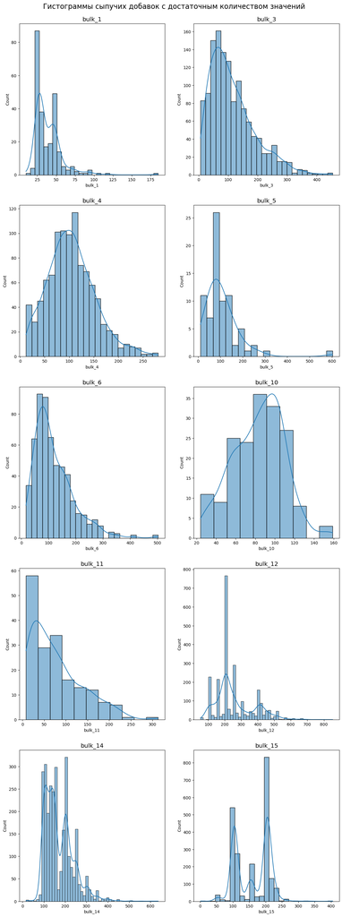

```python
fig, axs = plt.subplots(5, 2, figsize=(14, 35))
plt.suptitle('Гистограммы сыпучих добавок с достаточным количеством значений', size='xx-large')
plt.subplots_adjust(top=.96);

for feature, ax in zip(bulk.drop(['bulk_2', 'bulk_8', 'bulk_7', 'bulk_9', 'bulk_13'], axis=1), axs.flatten()):
    plt.sca(ax)
    sns.histplot(bulk[feature], kde=True)
    plt.title(feature)
```

Рассматривая распределения столбцов с более 30 значениями можно увидеть, что каждое распределение довольно разное:

У многих графиков есть правые хвосты, однако учитывая, что целью работы является сократить затраты электроэнергии отбрасывать их, при этом отказываясь от данных о ситуациях которые могут вызвать необычные затраты не уместно.

Рассмотрим наиболее выраженные отклонения - 1, 5, 6 - чтобы убедится что аномалии не создают проблем с другими датафреймами.

```python
suspect_keys_bulk = bulk.query('bulk_1 > 160 or bulk_5 > 500 or bulk_6 > 400').index

bulk[bulk.index.isin(suspect_keys_bulk)]
```

| key | bulk_1 | bulk_2 | bulk_3 | bulk_4 | bulk_5 | bulk_6 | bulk_7 | bulk_8 | bulk_9 | bulk_10 | bulk_11 | bulk_12 | bulk_13 | bulk_14 | bulk_15 |
| --- | --- | --- | --- | --- | --- | --- | --- | --- | --- | --- | --- | --- | --- | --- | --- |
| 322 | 185.0 | NaN | 101.0 | 58.0 | NaN | NaN | 406.0 | NaN | NaN | NaN | NaN | 260.47102 | NaN | 636.0 | NaN |
| 1269 | NaN | NaN | 163.0 | NaN | NaN | 503.0 | NaN | NaN | NaN | NaN | NaN | NaN | NaN | 304.0 | 203.0 |
| 1808 | NaN | NaN | 226.0 | 30.0 | 603.0 | NaN | NaN | NaN | NaN | NaN | NaN | 210.00000 | NaN | 99.0 | 104.0 |
| 1963 | NaN | NaN | 118.0 | NaN | NaN | 407.0 | NaN | NaN | NaN | NaN | NaN | NaN | NaN | 217.0 | NaN |
| 2631 | NaN | NaN | 204.0 | NaN | NaN | 414.0 | NaN | NaN | NaN | NaN | NaN | 58.00000 | NaN | 198.0 | 106.0 |
| 2633 | NaN | NaN | 250.0 | NaN | NaN | 498.0 | NaN | NaN | NaN | NaN | NaN | 58.00000 | NaN | 194.0 | 108.0 |

Ключ 322 вызывает сомнения уже второй раз, возможно это была необычная партия, но его уместно отбросить дабы избежать искажения. Добавим к отброшенным.

```python
discard_keys += [322]
suspect_keys_bulk = suspect_keys_bulk.drop(322)
```

```python
temp[temp.key.isin(suspect_keys_bulk)]
```

|  | key | time | temp |
| --- | --- | --- | --- |
| 7081 | 1269 | 2019-06-20 09:18:08 | 1627.0 |
| 7082 | 1269 | 2019-06-20 09:24:20 | 1615.0 |
| 7083 | 1269 | 2019-06-20 10:40:53 | 1604.0 |
| 7084 | 1269 | 2019-06-20 10:44:23 | 1601.0 |
| 7085 | 1269 | 2019-06-20 10:47:45 | 1568.0 |
| 7086 | 1269 | 2019-06-20 10:56:35 | 1568.0 |
| 7087 | 1269 | 2019-06-20 11:02:42 | 1582.0 |
| 7088 | 1269 | 2019-06-20 11:13:19 | 1575.0 |
| 7089 | 1269 | 2019-06-20 11:24:34 | 1581.0 |
| 7090 | 1269 | 2019-06-20 11:29:41 | 1584.0 |
| 10100 | 1808 | 2019-07-09 14:34:30 | 1608.0 |
| 10101 | 1808 | 2019-07-09 14:42:25 | 1596.0 |
| 10102 | 1808 | 2019-07-09 14:54:21 | 1597.0 |
| 10998 | 1963 | 2019-07-21 22:58:20 | 1619.0 |
| 10999 | 1963 | 2019-07-21 23:08:36 | 1613.0 |
| 11000 | 1963 | 2019-07-21 23:38:04 | 1599.0 |
| 11001 | 1963 | 2019-07-21 23:46:54 | 1589.0 |
| 11002 | 1963 | 2019-07-21 23:54:23 | 1596.0 |
| 11003 | 1963 | 2019-07-21 23:57:04 | 1603.0 |
| 11004 | 1963 | 2019-07-22 00:07:13 | 1597.0 |
| 14693 | 2631 | 2019-08-15 10:59:30 | 1574.0 |
| 14694 | 2631 | 2019-08-15 11:03:51 | NaN |
| 14695 | 2631 | 2019-08-15 11:10:44 | NaN |
| 14696 | 2631 | 2019-08-15 11:18:10 | NaN |
| 14697 | 2631 | 2019-08-15 11:24:45 | NaN |
| 14698 | 2631 | 2019-08-15 11:34:41 | NaN |
| 14699 | 2631 | 2019-08-15 11:52:30 | NaN |
| 14700 | 2631 | 2019-08-15 11:55:31 | NaN |
| 14701 | 2631 | 2019-08-15 12:01:21 | NaN |
| 14702 | 2631 | 2019-08-15 12:11:47 | NaN |
| 14703 | 2631 | 2019-08-15 12:18:30 | NaN |
| 14712 | 2633 | 2019-08-15 13:49:39 | 1596.0 |
| 14713 | 2633 | 2019-08-15 13:56:56 | NaN |
| 14714 | 2633 | 2019-08-15 14:06:22 | NaN |
| 14715 | 2633 | 2019-08-15 14:18:14 | NaN |
| 14716 | 2633 | 2019-08-15 14:28:11 | NaN |
| 14717 | 2633 | 2019-08-15 14:30:22 | NaN |
| 14718 | 2633 | 2019-08-15 14:38:20 | NaN |

2631 и 2633 не имеют целевого признака - данных о температуре розлива - как следствие их следует отбросить.

```python
discard_keys += [2631, 2633]
suspect_keys_bulk = suspect_keys_bulk.drop([2631, 2633])
```

```python
bulk_time[bulk_time.index.isin(suspect_keys_bulk)]
```

| key | bulk_1 | bulk_2 | bulk_3 | bulk_4 | bulk_5 | bulk_6 | bulk_7 | bulk_8 | bulk_9 | bulk_10 | bulk_11 | bulk_12 | bulk_13 | bulk_14 | bulk_15 |
| --- | --- | --- | --- | --- | --- | --- | --- | --- | --- | --- | --- | --- | --- | --- | --- |
| 1269 | NaT | NaT | 2019-06-20 11:27:35 | NaT | NaT | 2019-06-20 11:17:48 | NaT | NaT | NaT | NaT | NaT | NaT | NaT | 2019-06-20 11:05:44 | 2019-06-20 11:00:13 |
| 1808 | NaT | NaT | 2019-07-09 14:36:47 | 2019-07-09 14:36:47 | 2019-07-09 14:36:47 | NaT | NaT | NaT | NaT | NaT | NaT | 2019-07-09 14:36:47 | NaT | 2019-07-09 14:36:47 | 2019-07-09 14:48:34 |
| 1963 | NaT | NaT | 2019-07-21 23:58:52 | NaT | NaT | 2019-07-21 23:56:15 | NaT | NaT | NaT | NaT | NaT | NaT | NaT | 2019-07-21 23:50:02 | NaT |

```python
arc[arc.key.isin(suspect_keys_bulk)]
```

|  | key | start | end | act_pow | react_pow | apparent_pow | duration | work |
| --- | --- | --- | --- | --- | --- | --- | --- | --- |
| 5825 | 1269 | 2019-06-20 09:18:18 | 2019-06-20 09:20:22 | 0.443400 | 0.330179 | 0.552831 | 124 | 68.551001 |
| 5826 | 1269 | 2019-06-20 09:24:30 | 2019-06-20 09:26:46 | 0.428233 | 0.279001 | 0.511102 | 136 | 69.509846 |
| 5827 | 1269 | 2019-06-20 10:41:03 | 2019-06-20 10:42:51 | 0.610578 | 0.493589 | 0.785134 | 108 | 84.794486 |
| 5828 | 1269 | 2019-06-20 10:44:33 | 2019-06-20 10:45:44 | 0.409215 | 0.306651 | 0.511363 | 71 | 36.306748 |
| 5829 | 1269 | 2019-06-20 10:47:55 | 2019-06-20 10:51:27 | 1.296445 | 1.063567 | 1.676885 | 212 | 355.499689 |
| 5830 | 1269 | 2019-06-20 10:56:45 | 2019-06-20 11:00:01 | 0.937671 | 0.661512 | 1.147530 | 196 | 224.915874 |
| 5831 | 1269 | 2019-06-20 11:02:52 | 2019-06-20 11:05:24 | 1.286677 | 0.903709 | 1.572332 | 152 | 238.994451 |
| 5832 | 1269 | 2019-06-20 11:13:29 | 2019-06-20 11:17:38 | 0.658315 | 0.514630 | 0.835597 | 249 | 208.063702 |
| 5833 | 1269 | 2019-06-20 11:24:44 | 2019-06-20 11:27:22 | 0.828117 | 0.538810 | 0.987975 | 158 | 156.100001 |
| 8307 | 1808 | 2019-07-09 14:34:40 | 2019-07-09 14:36:37 | 0.565013 | 0.420247 | 0.704164 | 117 | 82.387212 |
| 8308 | 1808 | 2019-07-09 14:42:35 | 2019-07-09 14:48:23 | 0.772482 | 0.498390 | 0.919305 | 348 | 319.918017 |
| 9050 | 1963 | 2019-07-21 22:58:30 | 2019-07-21 23:00:54 | 0.282641 | 0.224830 | 0.361157 | 144 | 52.006625 |
| 9051 | 1963 | 2019-07-21 23:08:46 | 2019-07-21 23:16:20 | 0.563754 | 0.371589 | 0.675201 | 454 | 306.541445 |
| 9052 | 1963 | 2019-07-21 23:38:14 | 2019-07-21 23:39:57 | 0.755048 | 0.664460 | 1.005786 | 103 | 103.595912 |
| 9053 | 1963 | 2019-07-21 23:47:04 | 2019-07-21 23:49:44 | 0.740720 | 0.481106 | 0.883249 | 160 | 141.319868 |
| 9054 | 1963 | 2019-07-21 23:54:33 | 2019-07-21 23:56:03 | 0.305433 | 0.236772 | 0.386459 | 90 | 34.781280 |
| 9055 | 1963 | 2019-07-21 23:57:14 | 2019-07-21 23:58:38 | 0.337405 | 0.246641 | 0.417940 | 84 | 35.106967 |

Явных аномалий с оставшимися тремя ключами не обнаружено.

**Выводы**

Некоторые столбцы имеют слишком мало значений чтобы иметь значительную пользу в предсказании, отбросив их можно несколько сократить время вычислений не особо влияя на качество модели.

Рассмотрены и обработаны аномалии.

В процессе задействованы, в добавок к текущему, датафреймы `temp`, `bulk_time` и `arc`. Можно увидеть что время в них описывает процесс шаг за шагом, а не совпадает - сначала замер температуры, потом либо добавки либо напрямую нагрев, потом снова измерение, и так пока температура не соответствует ожидаемой.

### 2.3. data_bulk_time_new.csv — данные о подаче сыпучих материалов (время);

```python
bulk_time.info()
```

```
<class 'pandas.core.frame.DataFrame'>
Int64Index: 3129 entries, 1 to 3241
Data columns (total 15 columns):
 #   Column   Non-Null Count  Dtype
---  ------   --------------  -----
 0   bulk_1   252 non-null    datetime64[ns]
 1   bulk_2   22 non-null     datetime64[ns]
 2   bulk_3   1298 non-null   datetime64[ns]
 3   bulk_4   1014 non-null   datetime64[ns]
 4   bulk_5   77 non-null     datetime64[ns]
 5   bulk_6   576 non-null    datetime64[ns]
 6   bulk_7   25 non-null     datetime64[ns]
 7   bulk_8   1 non-null      datetime64[ns]
 8   bulk_9   19 non-null     datetime64[ns]
 9   bulk_10  176 non-null    datetime64[ns]
 10  bulk_11  177 non-null    datetime64[ns]
 11  bulk_12  2450 non-null   datetime64[ns]
 12  bulk_13  18 non-null     datetime64[ns]
 13  bulk_14  2806 non-null   datetime64[ns]
 14  bulk_15  2248 non-null   datetime64[ns]
dtypes: datetime64[ns](15)
memory usage: 391.1 KB
```

```python
(bulk_time.isna() == bulk.isna()).all().all()
```

```
True
```

Пропуски соответствует пропусками `bulk`. Это значит, что для каждого значения в одной есть значение в другой отражающее время добавки.

```python
bulk_time
```

| key | bulk_1 | bulk_2 | bulk_3 | bulk_4 | bulk_5 | bulk_6 | bulk_7 | bulk_8 | bulk_9 | bulk_10 | bulk_11 | bulk_12 | bulk_13 | bulk_14 | bulk_15 |
| --- | --- | --- | --- | --- | --- | --- | --- | --- | --- | --- | --- | --- | --- | --- | --- |
| 1 | NaT | NaT | NaT | 2019-05-03 11:28:48 | NaT | NaT | NaT | NaT | NaT | NaT | NaT | 2019-05-03 11:24:31 | NaT | 2019-05-03 11:14:50 | 2019-05-03 11:10:43 |
| 2 | NaT | NaT | NaT | 2019-05-03 11:36:50 | NaT | NaT | NaT | NaT | NaT | NaT | NaT | 2019-05-03 11:53:30 | NaT | 2019-05-03 11:48:37 | 2019-05-03 11:44:39 |
| 3 | NaT | NaT | NaT | 2019-05-03 12:32:39 | NaT | NaT | NaT | NaT | NaT | NaT | NaT | 2019-05-03 12:27:13 | NaT | 2019-05-03 12:21:01 | 2019-05-03 12:16:16 |
| 4 | NaT | NaT | NaT | 2019-05-03 12:43:22 | NaT | NaT | NaT | NaT | NaT | NaT | NaT | 2019-05-03 12:58:00 | NaT | 2019-05-03 12:51:11 | 2019-05-03 12:46:36 |
| 5 | NaT | NaT | NaT | 2019-05-03 13:30:47 | NaT | NaT | NaT | NaT | NaT | NaT | NaT | 2019-05-03 13:30:47 | NaT | 2019-05-03 13:34:12 | 2019-05-03 13:30:47 |
| ... | ... | ... | ... | ... | ... | ... | ... | ... | ... | ... | ... | ... | ... | ... | ... |
| 3237 | NaT | NaT | 2019-09-06 11:54:15 | NaT | NaT | NaT | NaT | NaT | NaT | NaT | NaT | 2019-09-06 11:49:45 | NaT | 2019-09-06 11:45:22 | 2019-09-06 11:40:06 |
| 3238 | NaT | NaT | 2019-09-06 12:26:52 | NaT | NaT | NaT | NaT | NaT | NaT | NaT | NaT | 2019-09-06 12:18:35 | NaT | 2019-09-06 12:31:49 | 2019-09-06 12:26:52 |
| 3239 | NaT | NaT | NaT | NaT | NaT | 2019-09-06 15:06:00 | NaT | NaT | NaT | NaT | NaT | 2019-09-06 15:01:44 | NaT | 2019-09-06 14:58:15 | 2019-09-06 14:48:06 |
| 3240 | NaT | NaT | NaT | NaT | NaT | 2019-09-06 16:24:28 | NaT | NaT | NaT | NaT | NaT | NaT | NaT | 2019-09-06 16:07:29 | 2019-09-06 16:01:34 |
| 3241 | NaT | NaT | NaT | NaT | NaT | NaT | NaT | NaT | NaT | NaT | NaT | NaT | NaT | 2019-09-06 17:26:33 | 2019-09-06 17:23:15 |

3129 rows × 15 columns

Уместно провести проверку на вменяемость - убедится, что время в рамках других таблиц.

```python
temp_time = temp[['key', 'time']].groupby('key').agg([min, max]).droplevel(0, axis=1).rename({'min':'start', 'max':'end'}, axis=1)
temp_time
```

| key | start | end |
| --- | --- | --- |
| 1 | 2019-05-03 11:02:04 | 2019-05-03 11:30:38 |
| 2 | 2019-05-03 11:34:04 | 2019-05-03 11:55:09 |
| 3 | 2019-05-03 12:06:44 | 2019-05-03 12:35:57 |
| 4 | 2019-05-03 12:39:27 | 2019-05-03 12:59:47 |
| 5 | 2019-05-03 13:11:03 | 2019-05-03 13:36:39 |
| ... | ... | ... |
| 3237 | 2019-09-06 11:31:15 | 2019-09-06 11:55:45 |
| 3238 | 2019-09-06 12:16:15 | 2019-09-06 12:34:37 |
| 3239 | 2019-09-06 14:16:50 | 2019-09-06 15:09:55 |
| 3240 | 2019-09-06 15:25:21 | 2019-09-06 16:35:26 |
| 3241 | 2019-09-06 16:48:55 | 2019-09-06 17:30:05 |

3216 rows × 2 columns

```python
arc_time = arc[['key', 'start', 'end']].groupby('key').agg({'start': min, 'end': max})
arc_time
```

| key | start | end |
| --- | --- | --- |
| 1 | 2019-05-03 11:02:14 | 2019-05-03 11:28:37 |
| 2 | 2019-05-03 11:34:14 | 2019-05-03 11:53:18 |
| 3 | 2019-05-03 12:06:54 | 2019-05-03 12:32:19 |
| 4 | 2019-05-03 12:39:37 | 2019-05-03 12:57:50 |
| 5 | 2019-05-03 13:11:13 | 2019-05-03 13:33:55 |
| ... | ... | ... |
| 3237 | 2019-09-06 11:31:25 | 2019-09-06 11:53:55 |
| 3238 | 2019-09-06 12:16:25 | 2019-09-06 12:31:35 |
| 3239 | 2019-09-06 14:17:00 | 2019-09-06 15:05:50 |
| 3240 | 2019-09-06 15:25:31 | 2019-09-06 16:24:15 |
| 3241 | 2019-09-06 16:49:05 | 2019-09-06 17:26:15 |

3214 rows × 2 columns

Сначала оценка вменяемости таблиц `arc_time` и `temp_time`. В temp_time на две строки больше - это вышеупомянутые ковши без стадий добавок и нагрева дугой, подробней рассмотрены будут при предобработке `temp`. Отбросим их для сравнения таблиц.

```python
temp_time = temp_time[temp_time.index.isin(arc_time.index)]
temp_time
```

| key | start | end |
| --- | --- | --- |
| 1 | 2019-05-03 11:02:04 | 2019-05-03 11:30:38 |
| 2 | 2019-05-03 11:34:04 | 2019-05-03 11:55:09 |
| 3 | 2019-05-03 12:06:44 | 2019-05-03 12:35:57 |
| 4 | 2019-05-03 12:39:27 | 2019-05-03 12:59:47 |
| 5 | 2019-05-03 13:11:03 | 2019-05-03 13:36:39 |
| ... | ... | ... |
| 3237 | 2019-09-06 11:31:15 | 2019-09-06 11:55:45 |
| 3238 | 2019-09-06 12:16:15 | 2019-09-06 12:34:37 |
| 3239 | 2019-09-06 14:16:50 | 2019-09-06 15:09:55 |
| 3240 | 2019-09-06 15:25:21 | 2019-09-06 16:35:26 |
| 3241 | 2019-09-06 16:48:55 | 2019-09-06 17:30:05 |

3214 rows × 2 columns

```python
arc_time[(temp_time.start < arc_time.start) & (temp_time.end > arc_time.end)].shape
```

```
(3214, 2)
```

Таблицы вменяемы, первый замер каждой партии до первого этапа, последний после последнего.

```python
bulk_time.shape
```

```
(3129, 15)
```

```python
bulk_time[~bulk_time.index.isin(arc.key)].shape
```

```
(1, 15)
```

```python
bulk_time[bulk_time.index.isin(temp.key)].shape
```

```
(3129, 15)
```

```python
bulk_time[~bulk_time.index.isin(arc.key)]
```

| key | bulk_1 | bulk_2 | bulk_3 | bulk_4 | bulk_5 | bulk_6 | bulk_7 | bulk_8 | bulk_9 | bulk_10 | bulk_11 | bulk_12 | bulk_13 | bulk_14 | bulk_15 |
| --- | --- | --- | --- | --- | --- | --- | --- | --- | --- | --- | --- | --- | --- | --- | --- |
| 279 | NaT | NaT | NaT | NaT | NaT | 2019-05-14 10:13:37 | NaT | NaT | NaT | NaT | NaT | NaT | NaT | NaT | NaT |

```python
bulk[bulk.index==279]
```

| key | bulk_1 | bulk_2 | bulk_3 | bulk_4 | bulk_5 | bulk_6 | bulk_7 | bulk_8 | bulk_9 | bulk_10 | bulk_11 | bulk_12 | bulk_13 | bulk_14 | bulk_15 |
| --- | --- | --- | --- | --- | --- | --- | --- | --- | --- | --- | --- | --- | --- | --- | --- |
| 279 | NaN | NaN | NaN | NaN | NaN | 89.0 | NaN | NaN | NaN | NaN | NaN | NaN | NaN | NaN | NaN |

```python
temp[temp.key==279]
```

|  | key | time | temp |
| --- | --- | --- | --- |
| 1549 | 279 | 2019-05-14 10:13:01 | 1603.0 |

Одна из партий подозрительна, есть начальная температура, после неё добавка, и нет нагрева, или второго измерения температуры после добавки. Скорее всего аномалия, добавим к отбрасываемым.

```python
discard_keys += [279]
```

Учитывая, что анализ показал бессмысленность партии у которой только одно значение температуры, рассмотрим и отбросим вторую такую партию.

```python
temp.key.value_counts(ascending=True)[:2]
```

```
195    1
279    1
Name: key, dtype: int64
```

```python
temp[temp.key==195]
```

|  | key | time | temp |
| --- | --- | --- | --- |
| 1105 | 195 | 2019-05-11 00:01:36 | 1583.0 |

```python
arc[arc.key==195]
```

|  | key | start | end | act_pow | react_pow | apparent_pow | duration | work |
| --- | --- | --- | --- | --- | --- | --- | --- | --- |

```python
discard_keys += [195]
```

Вернёмся к оценке адекватности времени.

```python
arc_time_bulk = arc_time[arc_time.index.isin(bulk_time.index)]
temp_time_bulk = temp_time[temp_time.index.isin(bulk_time.index)]
```

```python
(bulk_time.drop(279).apply(lambda x: (temp_time_bulk.start < x) & (x < temp_time_bulk.end), axis=0) == ~bulk_time.drop(279).isna()).all(axis=1).all()
```

```
True
```

```python
(bulk_time.drop(279).apply(lambda x: (arc_time_bulk.start < x) & (x < arc_time_bulk.end), axis=0) == ~bulk_time.drop(279).isna()).all(axis=1).sum()
```

```
23
```

```python
(bulk_time.drop(279).apply(lambda x: (arc_time_bulk.start < x), axis=0) == ~bulk_time.drop(279).isna()).all(axis=1).all()
```

```
True
```

```python
(bulk_time.drop(279).apply(lambda x: (x < arc_time_bulk.end), axis=0) == ~bulk_time.drop(279).isna()).all(axis=1).sum()
```

```
23
```

```python
(bulk_time.drop(279).apply(lambda x: (x < arc_time_bulk.end), axis=0) == ~bulk_time.drop(279).isna()).all()
```

```
bulk_1     False
bulk_2     False
bulk_3     False
bulk_4     False
bulk_5     False
bulk_6     False
bulk_7     False
bulk_8      True
bulk_9     False
bulk_10    False
bulk_11    False
bulk_12    False
bulk_13    False
bulk_14    False
bulk_15    False
dtype: bool
```

Анализ показывает, что все сыпучие добавки, кроме исключённой, были сделаны после первого замера температуры до последнего, после начала первого этапа нагрева, но **не** до конца последнего - таких только 23, и кроме 8-й сыпучей добавки включенной только один раз, все добавлялись после последнего нагрева. Что значит, скорее всего, что добавки делаются в том числе и после стадий нагрева.

Это говорит о том, что, возможно, исключённые ввиду отсутствия этапов нагрева элементы имели удовлетворительный состав после первого измерения температуры была внесена небольшая коррекция и отправлены на дальнейшие стадии производства. Учитывая что целевым признаком является финальная температура, которая в их случае совпадает с начальной, они не подходят для МО, но возможно не являются ошибкой в данных.

**Выводы:**

Данный датафрейм содержит информацию о времени добавления сыпучих материалов, она полезна с точки зрении реконструкции технологического процесса и проверки смыслового содержания данных, однако в МО она применима только к в качестве индикатора порядка выполнения этапов в случае полной реконструкции тех. процесса поэтапно, учитывая, что это скорее всего излишне, возможно от использования этих данных в объединённой таблице стоит отказаться.

### 2.4. data_wire_new.csv — данные о проволочных материалах (объём);

```python
wire.info()
```

```
<class 'pandas.core.frame.DataFrame'>
Int64Index: 3081 entries, 1 to 3241
Data columns (total 9 columns):
 #   Column  Non-Null Count  Dtype
---  ------  --------------  -----
 0   wire_1  3055 non-null   float64
 1   wire_2  1079 non-null   float64
 2   wire_3  63 non-null     float64
 3   wire_4  14 non-null     float64
 4   wire_5  1 non-null      float64
 5   wire_6  73 non-null     float64
 6   wire_7  11 non-null     float64
 7   wire_8  19 non-null     float64
 8   wire_9  29 non-null     float64
dtypes: float64(9)
memory usage: 240.7 KB
```

Данный фрейм похож по структуре и особенностям на `bulk`, но имеет еще более ярко выраженную специфику - из 3000 значений `wire_1` присутствует практически во всех, `wire_2` около трети, остальные же менее чем в 2.5% данных. Возможно,пользы от них меньше чем оправдано затратами времени работы моделей на эти столбцы. `wire_3`, `wire_6`и даже `wire_9` можно включить, но не ясно насколько это оправдано. Возможно также стоит отказаться от `bulk_5` из сыпучих материалов, поскольку там тоже только около 2.5% партий подвержены его влиянию.

```python
wire
```

| key | wire_1 | wire_2 | wire_3 | wire_4 | wire_5 | wire_6 | wire_7 | wire_8 | wire_9 |
| --- | --- | --- | --- | --- | --- | --- | --- | --- | --- |
| 1 | 60.059998 | NaN | NaN | NaN | NaN | NaN | NaN | NaN | NaN |
| 2 | 96.052315 | NaN | NaN | NaN | NaN | NaN | NaN | NaN | NaN |
| 3 | 91.160157 | NaN | NaN | NaN | NaN | NaN | NaN | NaN | NaN |
| 4 | 89.063515 | NaN | NaN | NaN | NaN | NaN | NaN | NaN | NaN |
| 5 | 89.238236 | 9.11456 | NaN | NaN | NaN | NaN | NaN | NaN | NaN |
| ... | ... | ... | ... | ... | ... | ... | ... | ... | ... |
| 3237 | 38.088959 | NaN | NaN | NaN | NaN | NaN | NaN | NaN | NaN |
| 3238 | 56.128799 | NaN | NaN | NaN | NaN | NaN | NaN | NaN | NaN |
| 3239 | 143.357761 | NaN | NaN | NaN | NaN | NaN | NaN | NaN | NaN |
| 3240 | 34.070400 | NaN | NaN | NaN | NaN | NaN | NaN | NaN | NaN |
| 3241 | 63.117595 | NaN | NaN | NaN | NaN | NaN | NaN | NaN | NaN |

3081 rows × 9 columns

```python
wire.describe()
```

|  | wire_1 | wire_2 | wire_3 | wire_4 | wire_5 | wire_6 | wire_7 | wire_8 | wire_9 |
| --- | --- | --- | --- | --- | --- | --- | --- | --- | --- |
| count | 3055.000000 | 1079.000000 | 63.000000 | 14.000000 | 1.000 | 73.000000 | 11.000000 | 19.000000 | 29.000000 |
| mean | 100.895853 | 50.577323 | 189.482681 | 57.442841 | 15.132 | 48.016974 | 10.039007 | 53.625193 | 34.155752 |
| std | 42.012518 | 39.320216 | 99.513444 | 28.824667 | NaN | 33.919845 | 8.610584 | 16.881728 | 19.931616 |
| min | 1.918800 | 0.030160 | 0.144144 | 24.148801 | 15.132 | 0.034320 | 0.234208 | 45.076721 | 4.622800 |
| 25% | 72.115684 | 20.193680 | 95.135044 | 40.807002 | 15.132 | 25.053600 | 6.762756 | 46.094879 | 22.058401 |
| 50% | 100.158234 | 40.142956 | 235.194977 | 45.234282 | 15.132 | 42.076324 | 9.017009 | 46.279999 | 30.066399 |
| 75% | 126.060483 | 70.227558 | 276.252014 | 76.124619 | 15.132 | 64.212723 | 11.886057 | 48.089603 | 43.862003 |
| max | 330.314424 | 282.780152 | 385.008668 | 113.231044 | 15.132 | 180.454575 | 32.847674 | 102.762401 | 90.053604 |

Учитывая низкое количество записей в столбцах, детальный анализ имеет смысл в основном для первых двух. В обоих случаях есть довольно сильное отклонение максимума и минимума от q1 и q3

```python
wire[wire.wire_1 < 5].shape
```

```
(6, 9)
```

```python
wire[wire.wire_1 < 10].shape
```

```
(15, 9)
```

```python
wire[wire.wire_1 < 5]
```

| key | wire_1 | wire_2 | wire_3 | wire_4 | wire_5 | wire_6 | wire_7 | wire_8 | wire_9 |
| --- | --- | --- | --- | --- | --- | --- | --- | --- | --- |
| 1453 | 1.91880 | NaN | NaN | NaN | NaN | NaN | NaN | NaN | NaN |
| 2104 | 4.01856 | NaN | 90.138054 | 40.069122 | NaN | 78.078002 | NaN | NaN | NaN |
| 2106 | 4.06224 | NaN | 95.375282 | 113.231044 | NaN | 68.434087 | 5.035472 | NaN | NaN |
| 2110 | 3.10128 | NaN | 93.165077 | 56.078880 | NaN | 91.428487 | 0.234208 | NaN | NaN |
| 2566 | 2.09664 | NaN | 95.279190 | 47.224323 | NaN | 3.020157 | 9.134113 | NaN | NaN |
| 3215 | 4.06224 | NaN | NaN | NaN | NaN | NaN | NaN | NaN | NaN |

```python
pd.concat(
    [temp[temp.key.isin(wire[wire.wire_1 < 5].index)].drop_duplicates(subset='key', keep='first'),
    temp[temp.key.isin(wire[wire.wire_1 < 5].index)].drop_duplicates(subset='key', keep='last')]
).sort_index()
```

|  | key | time | temp |
| --- | --- | --- | --- |
| 8112 | 1453 | 2019-06-27 03:53:17 | 1583.0 |
| 8120 | 1453 | 2019-06-27 04:34:48 | 1590.0 |
| 11789 | 2104 | 2019-07-27 03:08:08 | 1629.0 |
| 11797 | 2104 | 2019-07-27 04:24:00 | 1626.0 |
| 11807 | 2106 | 2019-07-27 05:45:43 | 1602.0 |
| 11815 | 2106 | 2019-07-27 07:52:57 | 1545.0 |
| 11850 | 2110 | 2019-07-27 19:09:10 | 1645.0 |
| 11855 | 2110 | 2019-07-27 21:12:52 | 1551.0 |
| 14325 | 2566 | 2019-08-13 02:49:33 | 1613.0 |
| 14333 | 2566 | 2019-08-13 04:50:42 | NaN |
| 17949 | 3215 | 2019-09-05 19:01:40 | 1547.0 |
| 17951 | 3215 | 2019-09-05 19:09:10 | NaN |

```python
arc[arc.key.isin(wire[wire.wire_1 < 5].index)].groupby('key')['work'].agg('sum')
```

```
key
1453     557.525255
2104    1387.781066
2106    1093.666303
2110     266.771323
2566     732.134486
3215     121.575917
Name: work, dtype: float64
```

```python
discard_keys += [2566, 3215]
```

Рассматривая низкие значения `wire_1` нет чёткой закономерности в разрезе начальной/конечной температуры и работы совершённой для достижения результата. Два ключа будут отброшены ввиду отсутствия ЦП, но в остальном не зная больше о тех процессе нельзя сказать насколько аномальны данные значения.

```python
wire[wire.wire_1 > 200].shape
```

```
(43, 9)
```

```python
wire[wire.wire_1 > 250].shape
```

```
(2, 9)
```

```python
wire[wire.wire_1 > 250]
```

| key | wire_1 | wire_2 | wire_3 | wire_4 | wire_5 | wire_6 | wire_7 | wire_8 | wire_9 |
| --- | --- | --- | --- | --- | --- | --- | --- | --- | --- |
| 1464 | 280.987214 | NaN | NaN | NaN | NaN | NaN | NaN | NaN | NaN |
| 1821 | 330.314424 | 69.337838 | NaN | NaN | NaN | NaN | NaN | NaN | NaN |

```python
pd.concat(
    [temp[temp.key.isin(wire[wire.wire_1 > 250].index)].drop_duplicates(subset='key', keep='first'),
    temp[temp.key.isin(wire[wire.wire_1 > 250].index)].drop_duplicates(subset='key', keep='last')]
).sort_index()
```

|  | key | time | temp |
| --- | --- | --- | --- |
| 8181 | 1464 | 2019-06-27 14:36:50 | 1567.0 |
| 8185 | 1464 | 2019-06-27 15:25:45 | 1585.0 |
| 10176 | 1821 | 2019-07-10 02:59:57 | 1644.0 |
| 10181 | 1821 | 2019-07-10 04:03:25 | 1615.0 |

```python
arc[arc.key.isin(wire[wire.wire_1 > 250].index)].groupby('key')['work'].agg('sum')
```

```
key
1464    620.091715
1821    685.764991
Name: work, dtype: float64
```

C точки зрения статистики высокие значения `wire_1` - выбросы, но явных аномалий нет.

```python
wire[wire.wire_2 < 5].shape
```

```
(12, 9)
```

```python
wire[wire.wire_2 < 2].shape
```

```
(8, 9)
```

```python
wire[wire.wire_2 < 2]
```

| key | wire_1 | wire_2 | wire_3 | wire_4 | wire_5 | wire_6 | wire_7 | wire_8 | wire_9 |
| --- | --- | --- | --- | --- | --- | --- | --- | --- | --- |
| 116 | 146.022235 | 0.58240 | NaN | NaN | NaN | NaN | NaN | NaN | NaN |
| 140 | 165.197754 | 1.60160 | NaN | NaN | NaN | 20.214481 | NaN | NaN | NaN |
| 311 | 81.987354 | 0.17472 | NaN | NaN | NaN | NaN | NaN | NaN | NaN |
| 349 | 76.283997 | 0.03016 | NaN | NaN | NaN | NaN | NaN | NaN | NaN |
| 436 | 36.129601 | 0.09048 | NaN | NaN | NaN | NaN | NaN | NaN | NaN |
| 580 | 71.370002 | 1.17624 | NaN | NaN | NaN | NaN | NaN | NaN | NaN |
| 769 | 222.300003 | 0.09048 | NaN | NaN | NaN | NaN | NaN | NaN | NaN |
| 1313 | 150.134399 | 0.06032 | NaN | NaN | NaN | NaN | NaN | NaN | NaN |

```python
pd.concat(
    [temp[temp.key.isin(wire[wire.wire_2 < 2].index)].drop_duplicates(subset='key', keep='first'),
    temp[temp.key.isin(wire[wire.wire_2 < 2].index)].drop_duplicates(subset='key', keep='last')]
).sort_index()
```

|  | key | time | temp |
| --- | --- | --- | --- |
| 640 | 116 | 2019-05-07 20:07:55 | 1591.0 |
| 644 | 116 | 2019-05-07 20:45:02 | 1600.0 |
| 781 | 140 | 2019-05-08 23:46:05 | 1598.0 |
| 786 | 140 | 2019-05-09 00:27:14 | 1592.0 |
| 1741 | 311 | 2019-05-15 11:11:00 | 1572.0 |
| 1747 | 311 | 2019-05-15 11:52:08 | 1590.0 |
| 1968 | 349 | 2019-05-16 21:02:03 | 1605.0 |
| 1973 | 349 | 2019-05-16 21:54:57 | 1577.0 |
| 2455 | 436 | 2019-05-20 01:46:30 | 1593.0 |
| 2457 | 436 | 2019-05-20 01:54:59 | 1575.0 |
| 3233 | 580 | 2019-05-25 10:29:48 | 1559.0 |
| 3239 | 580 | 2019-05-25 11:19:11 | 1588.0 |
| 4300 | 769 | 2019-06-02 13:56:11 | 1586.0 |
| 4307 | 769 | 2019-06-02 14:40:52 | 1595.0 |
| 7324 | 1313 | 2019-06-21 22:04:07 | 1599.0 |
| 7328 | 1313 | 2019-06-21 22:33:40 | 1611.0 |

```python
arc[arc.key.isin(wire[wire.wire_2 < 2].index)].groupby('key')['work'].agg('sum')
```

```
key
116      643.846889
140      472.023934
311      746.747061
349      500.897400
436      185.532320
580     1469.502352
769      683.424652
1313     589.474667
Name: work, dtype: float64
```

Низкие значения `wire_2` тоже не создают явных проблем, есть одно аномально высокое значение работы, но его имеет смысл рассматривать в рамках объединённой таблицы.

```python
wire[wire.wire_2 > 150].shape
```

```
(30, 9)
```

```python
wire[wire.wire_2 > 200].shape
```

```
(6, 9)
```

```python
wire[wire.wire_2 > 200]
```

| key | wire_1 | wire_2 | wire_3 | wire_4 | wire_5 | wire_6 | wire_7 | wire_8 | wire_9 |
| --- | --- | --- | --- | --- | --- | --- | --- | --- | --- |
| 626 | 100.151992 | 210.245362 | NaN | NaN | NaN | NaN | NaN | NaN | NaN |
| 928 | 115.034401 | 215.432892 | NaN | NaN | NaN | NaN | NaN | NaN | NaN |
| 953 | 110.120399 | 231.568481 | NaN | NaN | NaN | NaN | NaN | NaN | NaN |
| 1269 | 142.365600 | 282.780152 | NaN | NaN | NaN | NaN | NaN | NaN | NaN |
| 1377 | 169.135192 | 220.348953 | NaN | NaN | NaN | NaN | NaN | NaN | NaN |
| 2508 | 175.637275 | 219.866410 | 268.348081 | NaN | NaN | NaN | NaN | NaN | NaN |

```python
pd.concat(
    [temp[temp.key.isin(wire[wire.wire_2 >  200].index)].drop_duplicates(subset='key', keep='first'),
    temp[temp.key.isin(wire[wire.wire_2 > 200].index)].drop_duplicates(subset='key', keep='last')]
).sort_index()
```

|  | key | time | temp |
| --- | --- | --- | --- |
| 3489 | 626 | 2019-05-27 06:02:23 | 1636.0 |
| 3494 | 626 | 2019-05-27 07:07:03 | 1578.0 |
| 5240 | 928 | 2019-06-08 12:00:21 | 1588.0 |
| 5245 | 928 | 2019-06-08 12:47:45 | 1609.0 |
| 5368 | 953 | 2019-06-09 11:40:43 | 1537.0 |
| 5374 | 953 | 2019-06-09 12:19:18 | 1578.0 |
| 7081 | 1269 | 2019-06-20 09:18:08 | 1627.0 |
| 7090 | 1269 | 2019-06-20 11:29:41 | 1584.0 |
| 7692 | 1377 | 2019-06-24 11:23:37 | 1571.0 |
| 7698 | 1377 | 2019-06-24 12:00:21 | 1604.0 |
| 13974 | 2508 | 2019-08-10 20:41:22 | 1586.0 |
| 13981 | 2508 | 2019-08-10 21:26:27 | NaN |

```python
arc[arc.key.isin(wire[wire.wire_2 > 200].index)].groupby('key')['work'].agg('sum')
```

```
key
626      630.714148
928     1399.063915
953     1049.763450
1269    1442.735798
1377     568.499215
2508     826.919748
Name: work, dtype: float64
```

```python
discard_keys += [2508]
```

Среди высоких значений `wire_2` наиболее подозрительным является ключ `2508`, к счастью у него нет ЦП поэтому его можно отбросить. В ходе анализа становится понятно, что уместней было бы начать с анализа датафрейма `temp` содержащего ЦП, т.к. аномалии в нём зачастую связаны с аномалиями в других, однако нарушать порядок уже нецелесообразно.

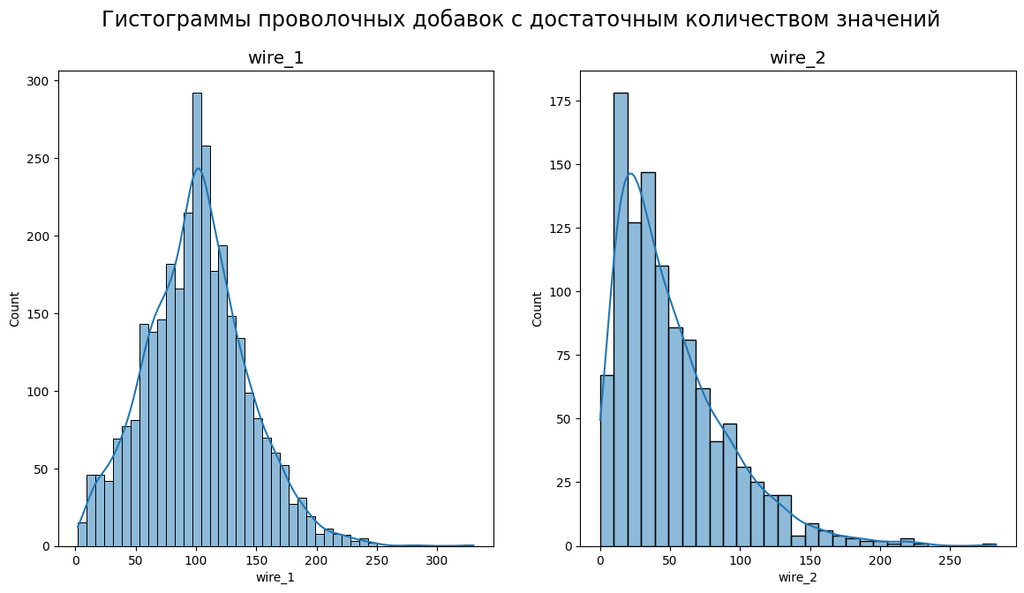

```python
fig, axs = plt.subplots(1, 2, figsize=(14, 7))
plt.suptitle('Гистограммы проволочных добавок с достаточным количеством значений', size='xx-large')

for feature, ax in zip([wire.wire_1, wire.wire_2], axs.flatten()):
    plt.sca(ax)
    sns.histplot(feature, kde=True)
    plt.title(feature.name)
```

`wire_1` имеет нормальное распределение, `wire_2` пуассоновское. Данные в целом качественны, несмотря на выраженные правые хвосты.

**Выводы**

Аналогично с `bulk` есть столбцы, которые имеют слишком мало значений чтобы иметь значительную пользу в предсказании, здесь их большинство и их стоит отбросить.

Аномалии сложно оценить, есть статистические выбросы - слишком большие и малые значения чтобы - но не зная деталей тех процесса сложно сказать вызваны они им, или ошибкой в данных. Наиболее явные - те в которых отсутствует ЦП, что говорит о том, что, в дальнейшем, предобработку и анализ данных этой задачи лучше начинать с датафрейма `temp`.

### 2.5. data_wire_time_new.csv — данные о проволочных материалах (время);

Анализ данного фрейма имеет смысл проводить по аналогии с bulk_time. В первую очередь интересуют данные о `wire_1`, `wire_2, из-за низкого количества значений в других столбцах.

```python
wire_time.info()
```

```
<class 'pandas.core.frame.DataFrame'>
Int64Index: 3081 entries, 1 to 3241
Data columns (total 9 columns):
 #   Column  Non-Null Count  Dtype
---  ------  --------------  -----
 0   wire_1  3055 non-null   datetime64[ns]
 1   wire_2  1079 non-null   datetime64[ns]
 2   wire_3  63 non-null     datetime64[ns]
 3   wire_4  14 non-null     datetime64[ns]
 4   wire_5  1 non-null      datetime64[ns]
 5   wire_6  73 non-null     datetime64[ns]
 6   wire_7  11 non-null     datetime64[ns]
 7   wire_8  19 non-null     datetime64[ns]
 8   wire_9  29 non-null     datetime64[ns]
dtypes: datetime64[ns](9)
memory usage: 240.7 KB
```

```python
(wire_time.isna() == wire.isna()).all().all()
```

```
True
```

Пропуски соответствует пропусками `wire`.

```python
wire_time
```

| key | wire_1 | wire_2 | wire_3 | wire_4 | wire_5 | wire_6 | wire_7 | wire_8 | wire_9 |
| --- | --- | --- | --- | --- | --- | --- | --- | --- | --- |
| 1 | 2019-05-03 11:06:19 | NaT | NaT | NaT | NaT | NaT | NaT | NaT | NaT |
| 2 | 2019-05-03 11:36:50 | NaT | NaT | NaT | NaT | NaT | NaT | NaT | NaT |
| 3 | 2019-05-03 12:11:46 | NaT | NaT | NaT | NaT | NaT | NaT | NaT | NaT |
| 4 | 2019-05-03 12:43:22 | NaT | NaT | NaT | NaT | NaT | NaT | NaT | NaT |
| 5 | 2019-05-03 13:20:44 | 2019-05-03 13:15:34 | NaT | NaT | NaT | NaT | NaT | NaT | NaT |
| ... | ... | ... | ... | ... | ... | ... | ... | ... | ... |
| 3237 | 2019-09-06 11:33:38 | NaT | NaT | NaT | NaT | NaT | NaT | NaT | NaT |
| 3238 | 2019-09-06 12:18:35 | NaT | NaT | NaT | NaT | NaT | NaT | NaT | NaT |
| 3239 | 2019-09-06 14:36:11 | NaT | NaT | NaT | NaT | NaT | NaT | NaT | NaT |
| 3240 | 2019-09-06 15:33:55 | NaT | NaT | NaT | NaT | NaT | NaT | NaT | NaT |
| 3241 | 2019-09-06 17:10:06 | NaT | NaT | NaT | NaT | NaT | NaT | NaT | NaT |

3081 rows × 9 columns

Уместно провести проверку на вменяемость - убедится, что время в рамках других таблиц.

```python
wire_time.shape
```

```
(3081, 9)
```

```python
wire_time[~wire_time.index.isin(arc.key)].shape
```

```
(1, 9)
```

```python
wire_time[~wire_time.index.isin(temp.key)].shape
```

```
(0, 9)
```

```python
wire_time[~wire_time.index.isin(arc.key)]
```

| key | wire_1 | wire_2 | wire_3 | wire_4 | wire_5 | wire_6 | wire_7 | wire_8 | wire_9 |
| --- | --- | --- | --- | --- | --- | --- | --- | --- | --- |
| 279 | 2019-05-14 10:13:37 | NaT | NaT | NaT | NaT | NaT | NaT | NaT | NaT |

```python
discard_keys
```

```
[2701, 2985, 322, 2631, 2633, 279, 195, 2566, 3215, 2508]
```

Снова встречаем уже отброшенный ковш.

Вернёмся к оценке адекватности времени.

```python
arc_time_wire = arc_time[arc_time.index.isin(wire_time.drop(discard_keys, errors='ignore').index)]
temp_time_wire = temp_time[temp_time.index.isin(wire_time.drop(discard_keys, errors='ignore').index)]
```

```python
(wire_time.drop(discard_keys, errors='ignore').apply(
    lambda x: (temp_time_wire.start < x) & (x < temp_time_wire.end), axis=0) \
== ~wire_time.drop(discard_keys, errors='ignore').isna()).all(axis=1).all()
```

```
True
```

```python
(wire_time.drop(discard_keys, errors='ignore').apply(
    lambda x: (arc_time_wire.start < x) & (x < arc_time_wire.end), axis=0) \
== ~wire_time.drop(discard_keys, errors='ignore').isna()).all(axis=1).sum()
```

```
2927
```

```python
(wire_time.drop(discard_keys, errors='ignore').apply(
    lambda x: (arc_time_wire.start < x), axis=0) \
== ~wire_time.drop(discard_keys, errors='ignore').isna()).all(axis=1).all()
```

```
True
```

```python
(wire_time.drop(discard_keys, errors='ignore').apply(
    lambda x: (x < arc_time_wire.end), axis=0) \
== ~wire_time.drop(discard_keys, errors='ignore').isna()).all(axis=1).sum()
```

```
2927
```

```python
(wire_time.drop(discard_keys, errors='ignore').apply(
    lambda x: (x < arc_time_wire.end), axis=0) \
== ~wire_time.drop(discard_keys, errors='ignore').isna()).all()
```

```
wire_1    False
wire_2    False
wire_3    False
wire_4     True
wire_5     True
wire_6    False
wire_7     True
wire_8     True
wire_9    False
dtype: bool
```

```python
(wire_time.drop(discard_keys, errors='ignore').apply(
    lambda x: (x < arc_time_wire.end), axis=0) \
== ~wire_time.drop(discard_keys, errors='ignore').isna()).all()
```

```
wire_1    False
wire_2    False
wire_3    False
wire_4     True
wire_5     True
wire_6    False
wire_7     True
wire_8     True
wire_9    False
dtype: bool
```

```python
(wire_time.drop(discard_keys, errors='ignore').apply(
    lambda x: (x < arc_time_wire.end), axis=0) \
== ~wire_time.drop(discard_keys, errors='ignore').isna()).apply(lambda x: x.value_counts(), axis=0)
```

|  | wire_1 | wire_2 | wire_3 | wire_4 | wire_5 | wire_6 | wire_7 | wire_8 | wire_9 |
| --- | --- | --- | --- | --- | --- | --- | --- | --- | --- |
| False | 140 | 20 | 2 | NaN | NaN | 1 | NaN | NaN | 1 |
| True | 2932 | 3052 | 3070 | 3072.0 | 3072.0 | 3071 | 3072.0 | 3072.0 | 3071 |

**Выводы:**

Повторяется ситуация с `bulk_time`, т.е. датафрейм скорее всего не уместен в МО, поскольку время добавки не сказывается значительно на результате процесса.

### 2.6. data_gas_new.csv — данные о продувке сплава газом;

```python
gas.info()
```

```
<class 'pandas.core.frame.DataFrame'>
Int64Index: 3239 entries, 1 to 3241
Data columns (total 1 columns):
 #   Column  Non-Null Count  Dtype
---  ------  --------------  -----
 0   gas_1   3239 non-null   float64
dtypes: float64(1)
memory usage: 50.6 KB
```

```python
gas.duplicated().sum()
```

```
0
```

```python
gas.index.duplicated().sum()
```

```
0
```

```python
gas
```

| key | gas_1 |
| --- | --- |
| 1 | 29.749986 |
| 2 | 12.555561 |
| 3 | 28.554793 |
| 4 | 18.841219 |
| 5 | 5.413692 |
| ... | ... |
| 3237 | 5.543905 |
| 3238 | 6.745669 |
| 3239 | 16.023518 |
| 3240 | 11.863103 |
| 3241 | 12.680959 |

3239 rows × 1 columns

Пропусков нет. Дубликатов нет. Количество ключей выше чем в `arc` и `temp`. Что говорит о том, что данные содержат информацию о большем количестве партий. В отсутствии ЦП это информация не несёт пользы, имеет смысл сократить.

```python
gas = gas[gas.index.isin(temp.key)]
```

```python
gas.describe()
```

|  | gas_1 |
| --- | --- |
| count | 3214.000000 |
| mean | 11.081627 |
| std | 6.178331 |
| min | 0.008399 |
| 25% | 7.094724 |
| 50% | 9.855138 |
| 75% | 13.805623 |
| max | 77.995040 |

```python
gas[gas.gas_1 < 3].shape
```

```
(127, 1)
```

```python
gas[gas.gas_1 < 1].shape
```

```
(6, 1)
```

```python
gas[gas.gas_1 < 1]
```

| key | gas_1 |
| --- | --- |
| 195 | 0.374436 |
| 866 | 0.008399 |
| 954 | 0.364256 |
| 1047 | 0.016696 |
| 2240 | 0.863448 |
| 2241 | 0.992751 |

```python
discard_keys.sort()
discard_keys
```

```
[195, 279, 322, 2508, 2566, 2631, 2633, 2701, 2985, 3215]
```

```python
suspect_keys_gas = gas[(gas.gas_1 < 1) & ~(gas.index.isin(discard_keys))].index
gas.loc[suspect_keys_gas]
```

| key | gas_1 |
| --- | --- |
| 866 | 0.008399 |
| 954 | 0.364256 |
| 1047 | 0.016696 |
| 2240 | 0.863448 |
| 2241 | 0.992751 |

```python
pd.concat(
    [temp[temp.key.isin(suspect_keys_gas)].drop_duplicates(subset='key', keep='first'),
    temp[temp.key.isin(suspect_keys_gas)].drop_duplicates(subset='key', keep='last')]
).sort_index()
```

|  | key | time | temp |
| --- | --- | --- | --- |
| 4879 | 866 | 2019-06-06 07:20:50 | 1624.0 |
| 4882 | 866 | 2019-06-06 07:44:26 | 1620.0 |
| 5375 | 954 | 2019-06-09 12:50:37 | 1569.0 |
| 5378 | 954 | 2019-06-09 13:06:36 | 1585.0 |
| 5884 | 1047 | 2019-06-12 17:31:14 | 1596.0 |
| 5889 | 1047 | 2019-06-12 18:07:15 | 1617.0 |
| 12533 | 2240 | 2019-08-01 05:50:21 | 1555.0 |
| 12536 | 2240 | 2019-08-01 06:17:26 | 1579.0 |
| 12537 | 2241 | 2019-08-01 06:27:53 | 1586.0 |
| 12541 | 2241 | 2019-08-01 07:00:50 | 1583.0 |

```python
arc[arc.key.isin(suspect_keys_gas)].groupby('key')['work'].agg(sum)
```

```
key
866     220.633080
954     246.409276
1047    546.162902
2240    760.017767
2241    643.940094
Name: work, dtype: float64
```

```python
gas[gas.gas_1 > 50].shape
```

```
(5, 1)
```

```python
suspect_keys_gas_high = gas[(gas.gas_1 > 50) & ~(gas.index.isin(discard_keys))].index
gas.loc[suspect_keys_gas_high]
```

| key | gas_1 |
| --- | --- |
| 117 | 50.581035 |
| 280 | 60.935689 |
| 2110 | 52.142373 |
| 2570 | 51.380229 |

```python
pd.concat(
    [temp[temp.key.isin(suspect_keys_gas_high)].drop_duplicates(subset='key', keep='first'),
    temp[temp.key.isin(suspect_keys_gas_high)].drop_duplicates(subset='key', keep='last')]
).sort_index()
```

|  | key | time | temp |
| --- | --- | --- | --- |
| 645 | 117 | 2019-05-07 21:50:43 | 1625.0 |
| 651 | 117 | 2019-05-07 22:56:25 | 1604.0 |
| 1550 | 280 | 2019-05-14 11:12:45 | 1532.0 |
| 1559 | 280 | 2019-05-14 12:05:34 | 1600.0 |
| 11850 | 2110 | 2019-07-27 19:09:10 | 1645.0 |
| 11855 | 2110 | 2019-07-27 21:12:52 | 1551.0 |
| 14367 | 2570 | 2019-08-13 10:22:28 | 1608.0 |
| 14376 | 2570 | 2019-08-13 12:12:07 | NaN |

```python
discard_keys += [2570]
suspect_keys_gas_high = suspect_keys_gas_high.drop(2570)
```

```python
arc[arc.key.isin(suspect_keys_gas_high)].groupby('key')['work'].agg(sum)
```

```
key
117      619.135781
280     1040.907729
2110     266.771323
Name: work, dtype: float64
```

Рассматривая наименьшеи и наибольшие значения снова сложно говорить с уверенностью о природе аномалий. Добавлен к отброшенным еще одна партия без ЦП, более организованно к этому стоит подойти при обработке `temp` и формировании объединённой таблицы.

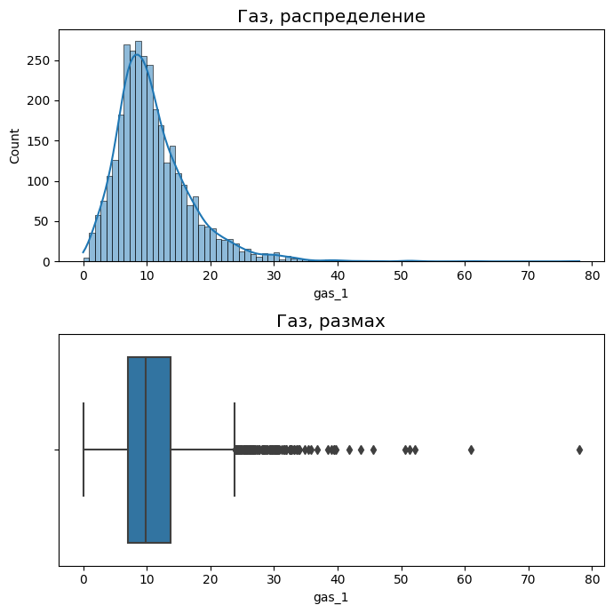

```python
plt.subplot(211)
sns.histplot(gas.gas_1, kde=True);
plt.title('Газ, распределение');
plt.subplot(212)
sns.boxplot(x=gas.gas_1)
plt.title('Газ, размах')
plt.tight_layout()
plt.show()
```

В целом нормальное распределение, но не очень гладкое. Огромный правый хвост с рассмотренными ранее значениями возможно уместно отбросить, но это может привести к потери возможности учитывать нештатные ситуации которые его вызвали, поскольку несмотря на размах выбросов, они математически возможны.

**Выводы**

Данный датафрейм хранит полезную и довольно простую для подключения к общей таблице информацию. Выбросы вызывают сомнения, но отбрасывать их произвольно не зная деталей процесса кажется не оправданным.

### 2.7. data_temp_new.csv — результаты измерения температуры.

Учитывая, что данный датафрейм содержит целевой признак, пожалуй наиболее важный из фреймов. В случае дальнейшей работы с информацией по данному производству анализ имеет смысл начинать именно с него.

```python
temp.info()
```

```
<class 'pandas.core.frame.DataFrame'>
RangeIndex: 18092 entries, 0 to 18091
Data columns (total 3 columns):
 #   Column  Non-Null Count  Dtype
---  ------  --------------  -----
 0   key     18092 non-null  int64
 1   time    18092 non-null  datetime64[ns]
 2   temp    14665 non-null  float64
dtypes: datetime64[ns](1), float64(1), int64(1)
memory usage: 424.2 KB
```

```python
temp.duplicated().sum()
```

```
0
```

```python
temp.drop('key', axis=1).describe()
```

|  | temp |
| --- | --- |
| count | 14665.000000 |
| mean | 1590.722741 |
| std | 20.394381 |
| min | 1191.000000 |
| 25% | 1580.000000 |
| 50% | 1590.000000 |
| 75% | 1599.000000 |
| max | 1705.000000 |

```python
temp[temp.temp < 1550].shape
```

```
(225, 3)
```

```python
temp[temp.temp < 1525].shape
```

```
(11, 3)
```

```python
suspect_keys_temp = pd.Index(temp[temp.temp < 1525].key.unique())
temp[(temp.key.isin(suspect_keys_temp)) & ~(temp.key.isin(discard_keys))]
```

|  | key | time | temp |
| --- | --- | --- | --- |
| 2881 | 512 | 2019-05-23 02:49:33 | 1520.0 |
| 2882 | 512 | 2019-05-23 02:55:06 | 1563.0 |
| 2883 | 512 | 2019-05-23 03:06:09 | 1564.0 |
| 2884 | 512 | 2019-05-23 03:13:50 | 1593.0 |
| 2885 | 512 | 2019-05-23 03:21:03 | 1596.0 |
| 2886 | 512 | 2019-05-23 03:29:17 | 1597.0 |
| 2887 | 512 | 2019-05-23 03:34:23 | 1597.0 |
| 4883 | 867 | 2019-06-06 08:03:39 | 1191.0 |
| 4884 | 867 | 2019-06-06 08:18:52 | 1575.0 |
| 4885 | 867 | 2019-06-06 08:22:38 | 1576.0 |
| 4886 | 867 | 2019-06-06 08:25:11 | 1571.0 |
| 4887 | 867 | 2019-06-06 08:29:49 | 1600.0 |
| 4888 | 867 | 2019-06-06 08:36:49 | 1522.0 |
| 4889 | 867 | 2019-06-06 08:43:02 | 1521.0 |
| 4890 | 867 | 2019-06-06 08:48:23 | 1599.0 |
| 5117 | 908 | 2019-06-07 14:32:37 | 1520.0 |
| 5118 | 908 | 2019-06-07 14:37:14 | 1558.0 |
| 5119 | 908 | 2019-06-07 14:48:15 | 1569.0 |
| 5120 | 908 | 2019-06-07 14:54:06 | 1558.0 |
| 5121 | 908 | 2019-06-07 15:01:25 | 1553.0 |
| 5122 | 908 | 2019-06-07 15:08:09 | 1574.0 |
| 6784 | 1214 | 2019-06-18 08:01:03 | 1208.0 |
| 6785 | 1214 | 2019-06-18 08:17:56 | 1608.0 |
| 6786 | 1214 | 2019-06-18 08:31:10 | 1608.0 |
| 6787 | 1214 | 2019-06-18 08:43:56 | 1591.0 |
| 9050 | 1619 | 2019-07-03 02:34:41 | 1218.0 |
| 9051 | 1619 | 2019-07-03 02:39:29 | 1623.0 |
| 9052 | 1619 | 2019-07-03 02:43:59 | 1590.0 |
| 9359 | 1671 | 2019-07-04 17:02:03 | 1519.0 |
| 9360 | 1671 | 2019-07-04 17:09:00 | 1557.0 |
| 9361 | 1671 | 2019-07-04 17:14:22 | 1558.0 |
| 9362 | 1671 | 2019-07-04 17:23:49 | 1552.0 |
| 9363 | 1671 | 2019-07-04 17:30:14 | 1549.0 |
| 9364 | 1671 | 2019-07-04 17:38:48 | 1580.0 |
| 11495 | 2052 | 2019-07-25 08:49:15 | 1227.0 |
| 11496 | 2052 | 2019-07-25 08:54:39 | 1592.0 |
| 11497 | 2052 | 2019-07-25 09:03:59 | 1590.0 |
| 11498 | 2052 | 2019-07-25 09:07:19 | 1591.0 |
| 11499 | 2052 | 2019-07-25 09:20:11 | 1515.0 |
| 11500 | 2052 | 2019-07-25 09:27:03 | 1592.0 |
| 14283 | 2561 | 2019-08-12 18:49:29 | 1204.0 |
| 14284 | 2561 | 2019-08-12 18:59:23 | NaN |
| 14285 | 2561 | 2019-08-12 19:06:26 | NaN |
| 14286 | 2561 | 2019-08-12 19:11:13 | NaN |
| 14287 | 2561 | 2019-08-12 19:17:08 | NaN |
| 14288 | 2561 | 2019-08-12 19:21:45 | NaN |

```python
discard_keys += [2561]
suspect_keys_temp = suspect_keys_temp.drop(2561)
```

Отброшен за отсутствием ЦП.

```python
suspect_keys_temp = pd.Index(temp[temp.temp < 1500].key.unique())
temp[(temp.key.isin(suspect_keys_temp)) & ~(temp.key.isin(discard_keys))]
```

|  | key | time | temp |
| --- | --- | --- | --- |
| 4883 | 867 | 2019-06-06 08:03:39 | 1191.0 |
| 4884 | 867 | 2019-06-06 08:18:52 | 1575.0 |
| 4885 | 867 | 2019-06-06 08:22:38 | 1576.0 |
| 4886 | 867 | 2019-06-06 08:25:11 | 1571.0 |
| 4887 | 867 | 2019-06-06 08:29:49 | 1600.0 |
| 4888 | 867 | 2019-06-06 08:36:49 | 1522.0 |
| 4889 | 867 | 2019-06-06 08:43:02 | 1521.0 |
| 4890 | 867 | 2019-06-06 08:48:23 | 1599.0 |
| 6784 | 1214 | 2019-06-18 08:01:03 | 1208.0 |
| 6785 | 1214 | 2019-06-18 08:17:56 | 1608.0 |
| 6786 | 1214 | 2019-06-18 08:31:10 | 1608.0 |
| 6787 | 1214 | 2019-06-18 08:43:56 | 1591.0 |
| 9050 | 1619 | 2019-07-03 02:34:41 | 1218.0 |
| 9051 | 1619 | 2019-07-03 02:39:29 | 1623.0 |
| 9052 | 1619 | 2019-07-03 02:43:59 | 1590.0 |
| 11495 | 2052 | 2019-07-25 08:49:15 | 1227.0 |
| 11496 | 2052 | 2019-07-25 08:54:39 | 1592.0 |
| 11497 | 2052 | 2019-07-25 09:03:59 | 1590.0 |
| 11498 | 2052 | 2019-07-25 09:07:19 | 1591.0 |
| 11499 | 2052 | 2019-07-25 09:20:11 | 1515.0 |
| 11500 | 2052 | 2019-07-25 09:27:03 | 1592.0 |

```python
arc[arc.key.isin(suspect_keys_temp)].drop_duplicates(subset='key')
```

|  | key | start | end | act_pow | react_pow | apparent_pow | duration | work |
| --- | --- | --- | --- | --- | --- | --- | --- | --- |
| 4028 | 867 | 2019-06-06 08:03:49 | 2019-06-06 08:06:04 | 1.362161 | 0.948663 | 1.659953 | 135 | 224.093660 |
| 5583 | 1214 | 2019-06-18 08:01:13 | 2019-06-18 08:02:43 | 0.460792 | 0.303613 | 0.551824 | 90 | 49.664192 |
| 7446 | 1619 | 2019-07-03 02:34:51 | 2019-07-03 02:37:08 | 0.429974 | 0.295056 | 0.521475 | 137 | 71.442010 |
| 9459 | 2052 | 2019-07-25 08:49:25 | 2019-07-25 08:50:57 | 0.492488 | 0.323616 | 0.589298 | 92 | 54.215386 |
| 11745 | 2561 | 2019-08-12 18:49:39 | 2019-08-12 18:52:39 | 0.780120 | 0.547868 | 0.953282 | 180 | 171.590759 |

Данные записи имеют очень низкую начальную температуру, при последующих замерах она нормализуется, но при этом не видно оправдывающих этот скачок значений в `arc`. Отбросим их.

```python
discard_keys += list(suspect_keys_temp)
```

```python
temp[temp.temp > 1680].shape
```

```
(13, 3)
```

```python
temp[temp.temp > 1700].shape
```

```
(2, 3)
```

Посмотрим правые выбросы на графиках, перед тем как решать что с ними делать, т.к. есть подозрение что их много.

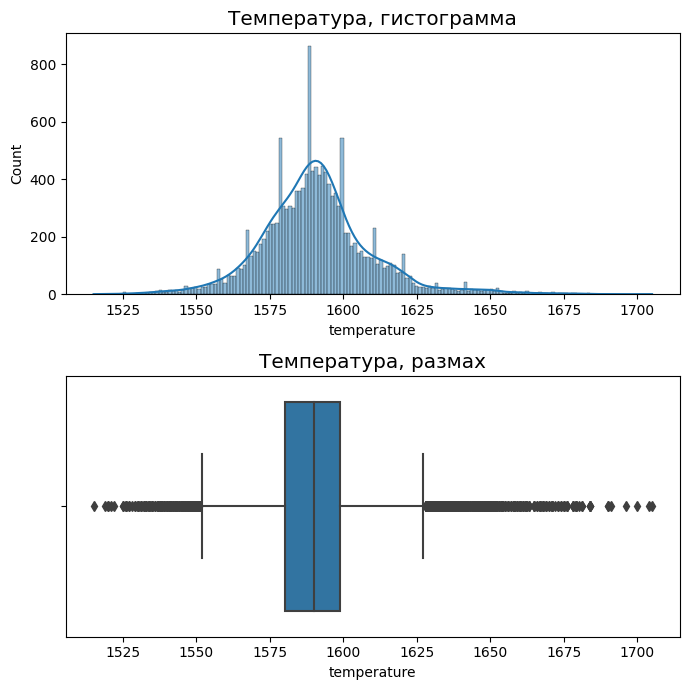

```python
plt.subplot(211)
sns.histplot(temp.temp[temp.temp > 1300], kde=True, bins=temp.temp.nunique())
plt.title("Температура, гистограмма")
plt.xlabel('temperature')

plt.subplot(212)
sns.boxplot(x=temp.temp[temp.temp > 1300])
plt.title("Температура, размах")
plt.xlabel('temperature')

plt.tight_layout()
plt.show()
```

Нормальное распределение с аномальными скачками количества в нескольких точках. Скачки наблюдаются по всему колоколу, возможно особенность процесса - например автоматическое выключение при определённой температурке. Выбросов много, за исключением обработанных выше, отбрасывать их не оправдано.

#### 2.7.1. Пропуски ЦП

Проверим последовательность времени в таблице.

```python
temp[temp.temp > 1680].shape
```

```
(13, 3)
```

```python
(temp.time > temp.time.shift())[1:].all()
```

```
False
```

```python
temp[~(temp.time > temp.time.shift())]
```

|  | key | time | temp |
| --- | --- | --- | --- |
| 0 | 1 | 2019-05-03 11:02:04 | 1571.0 |
| 1105 | 195 | 2019-05-11 00:01:36 | 1583.0 |

Первый ключ ожидаем, второй в списке отбрасываемых. Остальные в порядке, можно использовать отброс дубликатов для поиска последних значений.

```python
missing_target_keys = temp.drop_duplicates(subset='key', keep='last')
missing_target_keys = missing_target_keys[missing_target_keys.temp.isna()].key
missing_target_keys.shape
```

```
(739,)
```

```python
temp.key.nunique()
```

```
3216
```

Четверть ключей не имеют температуры разлива. Это говорит о серьёзных проблемах процесса сбора данных.

```python
temp.groupby('key')['temp'].agg(lambda x: x.isna().any()).sum()
```

```
739
```

При этом всего ключей с пропусками столько же, сколько пропусков ЦП.

```python
missing_initial_keys = temp.drop_duplicates(subset='key', keep='first')
missing_initial_keys = missing_initial_keys[missing_initial_keys.temp.isna()].key
missing_initial_keys.shape
```

```
(0,)
```

Несмотря на потери данных о температуре на стадиях после первой, начальные температура есть для всех, что говорит о том что либо она измеряется отличными от последующих методом, либо проблема возникла при переносе данных.

#### 2.7.2. Таблица температуры: начало - конец

Целевым признаком является температура розлива, промежуточные температуры на этапах становятся известны в процессе работы установки, начальная же известна сразу. Таким образом из значений в таблице нас в первую очередь интересует температура в начале и в конце для каждого ковша. В свою очередь время интересует только для понимания технологического процесса и проверке на вменяемость, проведённой выше в разделе `bulk_time`. Интерес к разнице между конечной и начальной температурой также делает данные, где есть только конечная температура не целесообразными. Они добавлены в список отбрасываемых значений ранее.

```python
temp_temperature = pd.concat(
    [
        temp[~(temp.key.isin(discard_keys)) & ~(temp.key.isin(missing_target_keys))] \
            .drop_duplicates(subset='key', keep='last').set_index('key')['temp'], # target первым для того, чтобы в дальнейшем проще было работать.
        temp[~(temp.key.isin(discard_keys)) & ~(temp.key.isin(missing_target_keys))] \
            .drop_duplicates(subset='key', keep='first').set_index('key')['temp']
    ], axis=1, keys=['temp_target', 'temp_initial']
)

temp_temperature
```

| key | temp_target | temp_initial |
| --- | --- | --- |
| 1 | 1613.0 | 1571.0 |
| 2 | 1602.0 | 1581.0 |
| 3 | 1599.0 | 1596.0 |
| 4 | 1625.0 | 1601.0 |
| 5 | 1602.0 | 1576.0 |
| ... | ... | ... |
| 2495 | 1591.0 | 1570.0 |
| 2496 | 1591.0 | 1554.0 |
| 2497 | 1589.0 | 1571.0 |
| 2498 | 1594.0 | 1591.0 |
| 2499 | 1603.0 | 1569.0 |

2470 rows × 2 columns

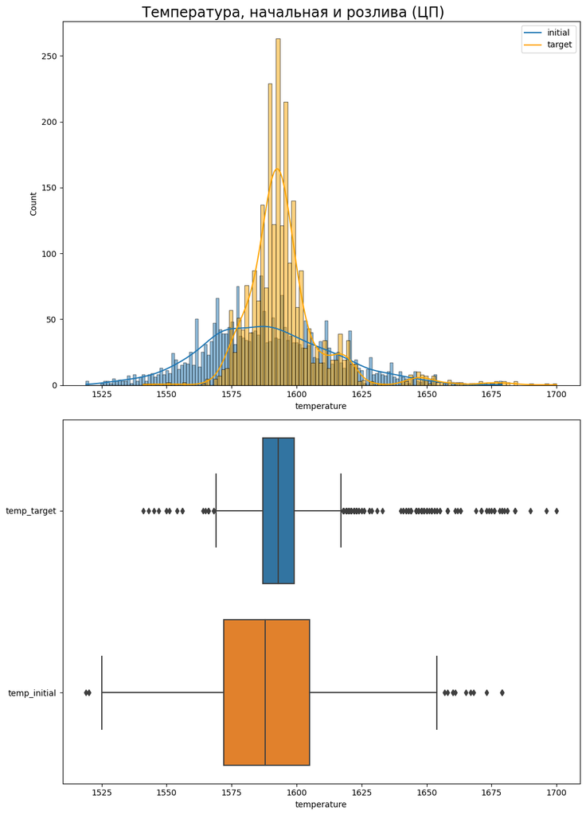

```python
plt.subplots(2, 1, figsize=(10, 14), sharex=True)
plt.suptitle("Температура, начальная и розлива (ЦП)", size='xx-large')
plt.subplot(211)
sns.histplot(temp_temperature.temp_initial, kde=True, bins=temp_temperature.temp_initial.nunique())
sns.histplot(temp_temperature.temp_target, kde=True, bins=temp_temperature.temp_target.nunique(), color='orange')
plt.legend(['initial', 'target'])
plt.xlabel('temperature')

plt.subplot(212)
sns.boxplot(data=temp_temperature, orient = "h")
plt.xlabel('temperature')

plt.tight_layout()
plt.show()
```

Оба распределения довольно хаотичны, колоколообразны, напоминают нормальное, но весьма далеки от него. Начальная температура имеет более широкое распределение. Температура розлива - узкое, но с достаточно большим количеством выбросов.

**Выводы:**

Температура ключевой параметр, и на основе составленной выше таблицы температур можно составить общую таблицу присоединяя к ней данные из других.

## 3. Объединение данных и Анализ объединённого датафрейма.

### 3.1. Объединение

Согласно требованиям проекта в объединенных данных должны быть ключи только те ключи, которые есть во всех датафреймах. Как следствие все присоединения эксклюзивные.

```python
final = temp_temperature.join(arc.groupby('key')['work'].agg(sum).rename({'sum':'work_total'}), how='inner')
final = final.join(gas, how='inner')
final = final.join(bulk[['bulk_1', 'bulk_3', 'bulk_4', 'bulk_6', 'bulk_10', 'bulk_11', 'bulk_12', 'bulk_14', 'bulk_15']], how='inner')
final = final.join(wire[['wire_1', 'wire_2']], how='inner')
final
```

| key | temp_target | temp_initial | work | gas_1 | bulk_1 | bulk_3 | bulk_4 | bulk_6 | bulk_10 | bulk_11 | bulk_12 | bulk_14 | bulk_15 | wire_1 | wire_2 |
| --- | --- | --- | --- | --- | --- | --- | --- | --- | --- | --- | --- | --- | --- | --- | --- |
| 1 | 1613.0 | 1571.0 | 770.282114 | 29.749986 | NaN | NaN | 43.0 | NaN | NaN | NaN | 206.0 | 150.0 | 154.0 | 60.059998 | NaN |
| 2 | 1602.0 | 1581.0 | 481.760005 | 12.555561 | NaN | NaN | 73.0 | NaN | NaN | NaN | 206.0 | 149.0 | 154.0 | 96.052315 | NaN |
| 3 | 1599.0 | 1596.0 | 722.837668 | 28.554793 | NaN | NaN | 34.0 | NaN | NaN | NaN | 205.0 | 152.0 | 153.0 | 91.160157 | NaN |
| 4 | 1625.0 | 1601.0 | 683.455597 | 18.841219 | NaN | NaN | 81.0 | NaN | NaN | NaN | 207.0 | 153.0 | 154.0 | 89.063515 | NaN |
| 5 | 1602.0 | 1576.0 | 512.169934 | 5.413692 | NaN | NaN | 78.0 | NaN | NaN | NaN | 203.0 | 151.0 | 152.0 | 89.238236 | 9.11456 |
| ... | ... | ... | ... | ... | ... | ... | ... | ... | ... | ... | ... | ... | ... | ... | ... |
| 2495 | 1591.0 | 1570.0 | 694.177326 | 7.125735 | NaN | 21.0 | NaN | NaN | 90.0 | NaN | 256.0 | 129.0 | 223.0 | 89.150879 | NaN |
| 2496 | 1591.0 | 1554.0 | 815.818538 | 9.412616 | NaN | NaN | 63.0 | NaN | 122.0 | NaN | 256.0 | 129.0 | 226.0 | 114.179527 | NaN |
| 2497 | 1589.0 | 1571.0 | 823.020520 | 6.271699 | NaN | NaN | 85.0 | NaN | NaN | NaN | 230.0 | 124.0 | 226.0 | 94.086723 | 9.04800 |
| 2498 | 1594.0 | 1591.0 | 581.810739 | 14.953657 | NaN | 90.0 | NaN | NaN | 101.0 | NaN | 206.0 | 129.0 | 207.0 | 118.110717 | NaN |
| 2499 | 1603.0 | 1569.0 | 532.386183 | 11.336151 | NaN | 47.0 | NaN | NaN | NaN | NaN | 233.0 | 126.0 | 227.0 | 110.160958 | 50.00528 |

2324 rows × 15 columns

### 3.2. Анализ

```python
final.info()
```

```
<class 'pandas.core.frame.DataFrame'>
Int64Index: 2324 entries, 1 to 2499
Data columns (total 15 columns):
 #   Column        Non-Null Count  Dtype
---  ------        --------------  -----
 0   temp_target   2324 non-null   float64
 1   temp_initial  2324 non-null   float64
 2   work          2324 non-null   float64
 3   gas_1         2324 non-null   float64
 4   bulk_1        198 non-null    float64
 5   bulk_3        957 non-null    float64
 6   bulk_4        810 non-null    float64
 7   bulk_6        438 non-null    float64
 8   bulk_10       143 non-null    float64
 9   bulk_11       130 non-null    float64
 10  bulk_12       1808 non-null   float64
 11  bulk_14       2064 non-null   float64
 12  bulk_15       1696 non-null   float64
 13  wire_1        2302 non-null   float64
 14  wire_2        808 non-null    float64
dtypes: float64(15)
memory usage: 290.5 KB
```

Рассмотрим пропуски.

```python
final.isna().sum()
```

```
temp_target        0
temp_initial       0
work               0
gas_1              0
bulk_1          2126
bulk_3          1367
bulk_4          1514
bulk_6          1886
bulk_10         2181
bulk_11         2194
bulk_12          516
bulk_14          260
bulk_15          628
wire_1            22
wire_2          1516
dtype: int64
```

Пропуски ожидаемы. Учитывая способ создания `inner`, ключи представлены во всех таблицах, убедимся, что нет строк, для которых данных по добавкам не нашлось.

```python
suspect_keys_final_bulk = final[final.iloc[:, 4:-3].apply(lambda x: x.isna().all(), axis=1)].index
final.loc[suspect_keys_final_bulk]
```

| key | temp_target | temp_initial | work | gas_1 | bulk_1 | bulk_3 | bulk_4 | bulk_6 | bulk_10 | bulk_11 | bulk_12 | bulk_14 | bulk_15 | wire_1 | wire_2 |
| --- | --- | --- | --- | --- | --- | --- | --- | --- | --- | --- | --- | --- | --- | --- | --- |
| 113 | 1647.0 | 1645.0 | 791.897474 | 25.377930 | NaN | NaN | NaN | NaN | NaN | NaN | NaN | NaN | NaN | 7.556640 | NaN |
| 114 | 1600.0 | 1631.0 | 279.085512 | 14.683228 | NaN | NaN | NaN | NaN | NaN | NaN | NaN | NaN | NaN | NaN | NaN |
| 1141 | 1602.0 | 1587.0 | 295.918293 | 3.767088 | NaN | NaN | NaN | NaN | NaN | NaN | NaN | NaN | NaN | 21.668399 | NaN |
| 1362 | 1556.0 | 1546.0 | 501.019248 | 6.170417 | NaN | NaN | NaN | NaN | NaN | NaN | NaN | NaN | NaN | 19.047600 | NaN |
| 1945 | 1554.0 | 1553.0 | 326.837964 | 8.088210 | NaN | NaN | NaN | NaN | NaN | NaN | NaN | NaN | NaN | 13.104000 | NaN |
| 1948 | 1550.0 | 1530.0 | 703.230506 | 10.406837 | NaN | NaN | NaN | NaN | NaN | NaN | NaN | NaN | NaN | 10.221120 | NaN |

```python
arc[arc.key == 114]
```

|  | key | start | end | act_pow | react_pow | apparent_pow | duration | work |
| --- | --- | --- | --- | --- | --- | --- | --- | --- |
| 518 | 114 | 2019-05-07 16:13:58 | 2019-05-07 16:16:18 | 0.580046 | 0.472979 | 0.748440 | 140 | 104.781606 |
| 519 | 114 | 2019-05-07 16:43:12 | 2019-05-07 16:46:45 | 0.313419 | 0.270347 | 0.413907 | 213 | 88.162182 |
| 520 | 114 | 2019-05-07 17:09:46 | 2019-05-07 17:12:32 | 0.415876 | 0.310373 | 0.518926 | 166 | 86.141724 |

```python
temp[temp.key==114]
```

|  | key | time | temp |
| --- | --- | --- | --- |
| 629 | 114 | 2019-05-07 16:13:48 | 1631.0 |
| 630 | 114 | 2019-05-07 16:43:02 | 1603.0 |
| 631 | 114 | 2019-05-07 17:09:36 | 1591.0 |
| 632 | 114 | 2019-05-07 17:32:39 | 1600.0 |

```python
bulk[bulk.index==114]
```

| key | bulk_1 | bulk_2 | bulk_3 | bulk_4 | bulk_5 | bulk_6 | bulk_7 | bulk_8 | bulk_9 | bulk_10 | bulk_11 | bulk_12 | bulk_13 | bulk_14 | bulk_15 |
| --- | --- | --- | --- | --- | --- | --- | --- | --- | --- | --- | --- | --- | --- | --- | --- |
| 114 | NaN | 247.0 | NaN | NaN | 79.0 | NaN | NaN | NaN | NaN | NaN | NaN | NaN | NaN | NaN | NaN |

```python
wire[wire.index==114]
```

| key | wire_1 | wire_2 | wire_3 | wire_4 | wire_5 | wire_6 | wire_7 | wire_8 | wire_9 |
| --- | --- | --- | --- | --- | --- | --- | --- | --- | --- |
| 114 | NaN | NaN | 88.648567 | 43.065361 | NaN | 54.122643 | NaN | NaN | NaN |

`114` выглядит проблематичным, но имеет информацию о добавках в отброшенных столбцах., скорее всего ситуация повторяется с другими строками, оставим их как есть, имеющейся информации скорее всего достаточно для приблизительной оценки.

В остальном, ввиду того как составлена таблица, данные целостны. Имеет смысл проверить корреляцию.

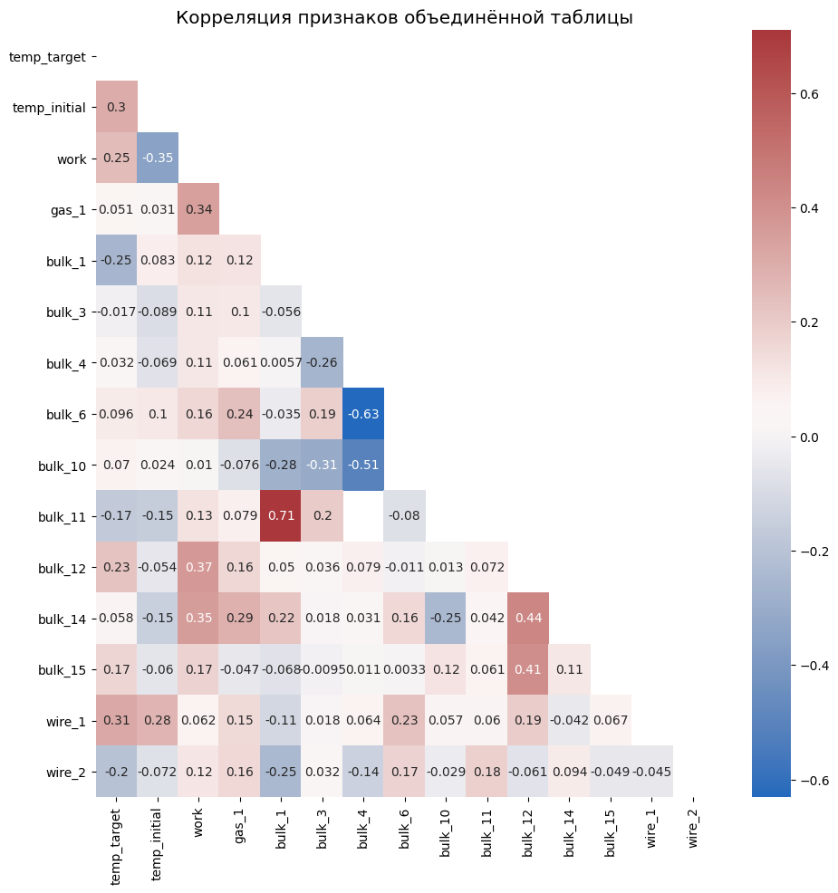

```python
corr_mtx = final.corr()
mask = np.triu(np.ones_like(corr_mtx, dtype=bool))


plt.figure(figsize=(11,11))
sns.heatmap(final.corr(), annot=True, mask=mask, cmap='vlag');
plt.title('Корреляция признаков объединённой таблицы');
```

Рассматривая целевую температуру, можно увидеть низкие корреляция с начальной, `wire_1`, `bulk_1`, и в меньшей степени рядом других параметров включая работу. Это даёт надежду на качество модели, и в то же время оправдывает использование МО, т.к. не одна из них не достаточно высокая чтобы принимать решения только на её основе.

```python
final.drop(['bulk_1', 'bulk_6', 'bulk_10'], axis=1, inplace=True)
```

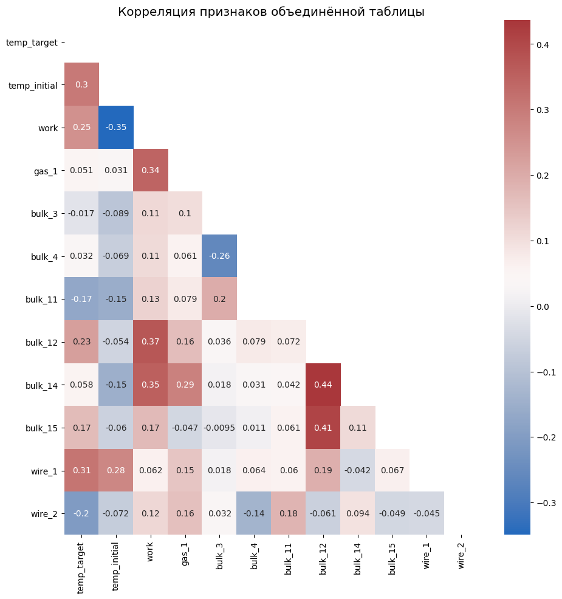

```python
corr_mtx = final.corr()
mask = np.triu(np.ones_like(corr_mtx, dtype=bool))


plt.figure(figsize=(11,11))
sns.heatmap(final.corr(), annot=True, mask=mask, cmap='vlag');
plt.title('Корреляция признаков объединённой таблицы');
```

**Выводы:**

Финальный датафрейм имеет значительно меньше признаков чем доступно в базе данных, но корреляция признаков ограничена 0.44 по модулю. Также отброшены столбцы с маленьким количеством записей, они не бесполезны но кратно усложняют обработка добавляя затраты вычислительных ресурсов, а значит времени, при этом не сильно влияют на результат.

Значительное число строк было отброшено из-за отсутствия ЦП, к сожалению с качеством данных ничего не поделаешь, а попытки искусственно восстановить ЦП обязательно исказят ДФ. Ряд строк был отброшен ввиду того что отсутствовал в одном из ДФ, согласно условиям проекта, такие строки могут быть информативны, если содержат наиболее важные показатели (например работу), но также понижают качество модели из-за недостатка информации. Небольшое количество строк отброшены ввиду наличия аномалий, таких строк можно отбросить больше, и получить более качественную модель, но каждая отброшенная это потеря данных, и на практике такой отсев может привести к необходимости чаще чем хотелось-бы обрабатывать данные в обход модели.

## 4. Машинное обучение.

### 4.1. Подготовка к МО.

```python
from sklearn.preprocessing import StandardScaler, MinMaxScaler
from sklearn.model_selection import train_test_split, RandomizedSearchCV, GridSearchCV, cross_val_score
from sklearn.metrics import mean_absolute_error as mae

from lightgbm import LGBMRegressor
from sklearn.linear_model import LinearRegression
from sklearn.ensemble import RandomForestRegressor
from catboost import CatBoostRegressor

import shap
```

```python
features = final.iloc[:, 1:].fillna(0)
target = final.iloc[:, 0]
```

```python
feat_train, feat_test, targ_train, targ_test = train_test_split(features, target, random_state=RANDOM)
```

```python
min_max = MinMaxScaler()
feat_train_mm = min_max.fit_transform(feat_train)
feat_test_mm = min_max.transform(feat_test)

scaler = StandardScaler()
feat_train_ss = scaler.fit_transform(feat_train)
feat_test_ss = scaler.transform(feat_test)
```

```python
evals_final = pd.DataFrame(columns=['Original', 'Standard', 'MinMax', 'SearchCV'])
```

```python
def scaler_check(model, evals_final):
    evals = pd.DataFrame(
        [[-cross_val_score(model, feat_train, targ_train, scoring='neg_mean_absolute_error').mean(),
        -cross_val_score(model, feat_train_ss, targ_train, scoring='neg_mean_absolute_error').mean(),
        -cross_val_score(model, feat_train_mm, targ_train, scoring='neg_mean_absolute_error').mean()
        ]], columns=['Original', 'Standard', 'MinMax'], index=[type(model).__name__]
    )

    display(evals)

    return pd.concat([evals_final, evals])
```

```python
def scv_results_add(clf, evals_final):

    e_score = -clf.best_score_
    e_index = type(clf.best_estimator_).__name__
    evals = pd.DataFrame(e_score, columns=['SearchCV'], index=[e_index])
    display(evals)
    evals_final.loc[e_index, 'SearchCV'] = e_score

    return evals_final
```

**Выводы:** Выделены признаки и ЦП. Отложена тестовая выборка. Инициализированы инструменты масштабирования и функция кросс валидации, позволяющая проверить с каким форматом данных модель справляется лучше.

### 4.2. Обучение моделей

Рассмотрим качество моделей на кросс валидации и составим ДФ содержащий результаты.

#### 4.2.1. Lin Reg

```python
lin_reg = LinearRegression()
evals_final = scaler_check(lin_reg, evals_final)
```

|  | Original | Standard | MinMax |
| --- | --- | --- | --- |
| LinearRegression | 6.919478 | 6.919478 | 6.919478 |

#### 4.2.2. LGBM

```python
lgbm = LGBMRegressor(random_state=RANDOM, verbose=0)
evals_final = scaler_check(lgbm, evals_final)
```

|  | Original | Standard | MinMax |
| --- | --- | --- | --- |
| LGBMRegressor | 7.062129 | 7.069594 | 7.068989 |

```python
%%time

parameters = {
    'boosting_type' : ['gbdt', 'dart'],
    'num_leaves': [50, 100, 200],
    'max_depth': [-1, 25, 50],
    'n_estimators' : [100, 150, 200],
    'learning_rate' : [0.1, .01, .001]
    }
clf_lgbm = RandomizedSearchCV(lgbm, parameters, verbose=2, scoring='neg_mean_absolute_error', n_jobs=4, random_state=RANDOM, n_iter=30) #classifier
clf_lgbm.fit(feat_train, targ_train)
evals_final = scv_results_add(clf_lgbm, evals_final)
```

[output not shown]

[output cut: 146 more lines]

[output not shown]

|  | SearchCV |
| --- | --- |
| LGBMRegressor | 6.940187 |

```
CPU times: total: 1.25 s
Wall time: 41.2 s
```

#### 4.2.3. Forest

```python
ran_fst = RandomForestRegressor(random_state=RANDOM)
evals_final = scaler_check(ran_fst, evals_final)
```

|  | Original | Standard | MinMax |
| --- | --- | --- | --- |
| RandomForestRegressor | 6.906265 | 6.918269 | 6.913934 |

```python
%%time

parameters = {
    'criterion': ["squared_error", "absolute_error", "friedman_mse", "poisson"],
    'max_depth': [None, 25, 50],
    'n_estimators' : [100, 150, 200]
    }
clf_ran_fst = RandomizedSearchCV(ran_fst, parameters, verbose=2, scoring='neg_mean_absolute_error', n_jobs=4, random_state=RANDOM, n_iter=30) #classifier
clf_ran_fst.fit(feat_train, targ_train)
evals_final = scv_results_add(clf_ran_fst, evals_final)
```

```
Fitting 5 folds for each of 30 candidates, totalling 150 fits
```

|  | SearchCV |
| --- | --- |
| RandomForestRegressor | 6.87437 |

```
CPU times: total: 20.9 s
Wall time: 3min 48s
```

#### 4.2.4. CatBoost

```python
cat_boost = CatBoostRegressor(random_state=RANDOM, verbose=0)
evals_final = scaler_check(cat_boost, evals_final)
```

|  | Original | Standard | MinMax |
| --- | --- | --- | --- |
| CatBoostRegressor | 6.934932 | 6.950977 | 6.947167 |

```python
%%time

parameters = {
    'loss_function' : ['MAE', 'RMSE'],
    'bootstrap_type' : ['Bayesian', 'Bernoulli'],
    'learning_rate' : [0.03, .01, .005],
    'l2_leaf_reg' : [ 2.5, 3.0, 3.5]
    }

clf_cat_boost = GridSearchCV(cat_boost, parameters, verbose=2, scoring='neg_mean_absolute_error', n_jobs=4) #classifier
clf_cat_boost.fit(feat_train_mm, targ_train)
evals_final = scv_results_add(clf_cat_boost, evals_final)
```

```
Fitting 5 folds for each of 36 candidates, totalling 180 fits
```

|  | SearchCV |
| --- | --- |
| CatBoostRegressor | 6.665224 |

```
CPU times: total: 7.48 s
Wall time: 6min 22s
```

### 4.3. Оценка моделей

```python
evals_final
```

|  | Original | Standard | MinMax | SearchCV |
| --- | --- | --- | --- | --- |
| LinearRegression | 6.919478 | 6.919478 | 6.919478 | NaN |
| LGBMRegressor | 7.062129 | 7.069594 | 7.068989 | 6.940187 |
| RandomForestRegressor | 6.906265 | 6.918269 | 6.913934 | 6.87437 |
| CatBoostRegressor | 6.934932 | 6.950977 | 6.947167 | 6.665224 |

```python
clf_cat_boost.best_estimator_.get_params()
```

```
{'loss_function': 'MAE',
 'verbose': 0,
 'random_state': 28122023,
 'bootstrap_type': 'Bernoulli',
 'l2_leaf_reg': 3.5,
 'learning_rate': 0.01}
```

```python
pd.DataFrame(clf_cat_boost.cv_results_).loc[clf_cat_boost.best_index_]
```

```
mean_fit_time                                                    8.157854
std_fit_time                                                     0.349066
mean_score_time                                                  0.024647
std_score_time                                                   0.010579
param_bootstrap_type                                            Bernoulli
param_l2_leaf_reg                                                     3.5
param_learning_rate                                                  0.01
param_loss_function                                                   MAE
params                  {'bootstrap_type': 'Bernoulli', 'l2_leaf_reg':...
split0_test_score                                               -6.772773
split1_test_score                                               -6.685983
split2_test_score                                               -6.013104
split3_test_score                                               -6.909601
split4_test_score                                               -6.944659
mean_test_score                                                 -6.665224
std_test_score                                                   0.339135
rank_test_score                                                         1
Name: 32, dtype: object
```

**Выводы:**

Среди моделей линейная регрессия и Случайный лес показывают лучшие результаты на кросс-валидации, однако с перебором гиперпараметров CatBoost вырывается вперёд, скорее всего вызвано достаточно большой `learning_rate` по умолчанию, с понижением результаты значительно улучшаются, но используется не самое низкое из доступных значение. Также используется бутстрап не по умолчанию и `MAE` в качестве функции потерь.

Значения на разных фолдах при кросс валидации сильно отличается. В среднем ниже целевого показателя, однако 2 из пяти превышают цель. Наиболее очевидный способ улучшить модель - отбросить сомнительные аномальные строки, выявленные при предобработке, однако без более подробной информации о технологическом процессе, сложно определить какие из аномальных значений ценны с точки зрения производства, какие вызваны его особенностями, а какие результат ошибки при переносе данных.

### 4.4. Контрольная выборка

```python
pd.DataFrame(mae(targ_test, clf_cat_boost.best_estimator_.predict(feat_test_mm)),
             index=[type(clf_cat_boost.best_estimator_).__name__], columns=['Test'])
```

|  | Test |
| --- | --- |
| CatBoostRegressor | 6.24478 |

**Выводы:**

Целевой уровень `MAE` достигнут. Примечательно, что значение ниже чем на кросс валидации. Скорее всего случайность, но предсказуемая - фолд представляет 20% от 75% - 15% а выборка 25%, таким образом результат ближе к среднему, но скорее всего для сток контрольной выборки доступно больше информации или меньше аномалий в ней.

#### 4.4.1. Проверка вменяемости

```python
pd.DataFrame(mae(targ_test, pd.Series(targ_train.mean(), index=targ_test.index)),
             index=['MeanDummy'], columns=['Test'])
```

|  | Test |
| --- | --- |
| MeanDummy | 7.785787 |

**Выводы:**

Модель значительно превосходит предсказание средним. МО оправдано.

### 4.5. Влияние признаков

```python
feature_importances = pd.DataFrame(clf_cat_boost.best_estimator_.feature_importances_, index=features.columns, columns=['feature_importances'])
feature_importances['feature_count'] = final.iloc[:, 1:].count().values
feature_importances
```

|  | feature_importances | feature_count |
| --- | --- | --- |
| temp_initial | 20.550110 | 2324 |
| work | 20.121397 | 2324 |
| gas_1 | 6.493851 | 2324 |
| bulk_3 | 3.799592 | 957 |
| bulk_4 | 4.692216 | 810 |
| bulk_11 | 1.063628 | 130 |
| bulk_12 | 7.883400 | 1808 |
| bulk_14 | 7.161617 | 2064 |
| bulk_15 | 7.323388 | 1696 |
| wire_1 | 13.177194 | 2302 |
| wire_2 | 7.733607 | 808 |

**Выводы:**

Начальная температура и работа показали себя наиболее важными показателями, не удивительно, ведь именно они говорят о том как получилась непосредственно финальная температура. Из остальных показателей примечателен `wire_1` который также оказывает значительное влияние, это объяснимо тем что он добавляется практически для всех ковшей. Худший результат у `bulk_11`, по тем же причинам - слишком мало значений. Примечателен gas_1, который показывает довольно низкие показатели несмотря на высокое количество значений, скорее всего объясняется технологическим процессом - газ меньше влияет на температуру чем добавки - но может быть аномалии мешаю.

#### 4.5.1. Shap

Воспользуемся библиотекой `shap` для более детального анализа признаков.

```python
explainer = shap.Explainer(clf_cat_boost.best_estimator_)
shap_values = explainer(feat_test)
```

**Влияние признаков по Shap**

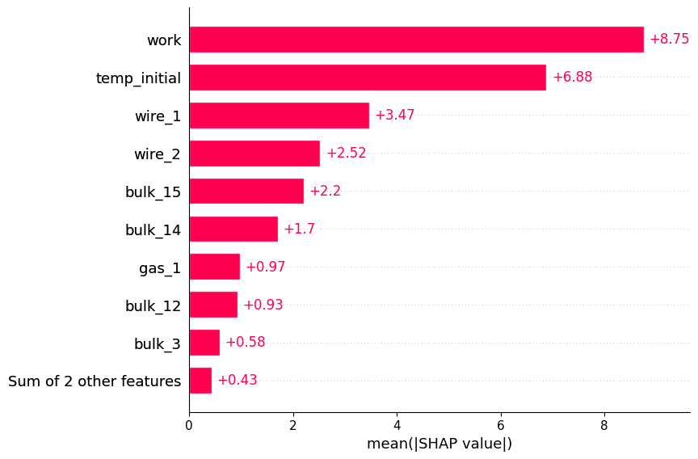

```python
shap.plots.bar(shap_values)
```

В отличии от указанных выше `feature_importances_` значения `shap` показывают среднее влияние параметра на значение предсказания. Тут можно увидеть, например, что газ слабо сказывается на значении, в то время как `wire_2`, `bulk_12`, несмотря на свою высокую важность, имеют разительно отличные друг от друга последствия для предсказания.

**Пример подсчёта**

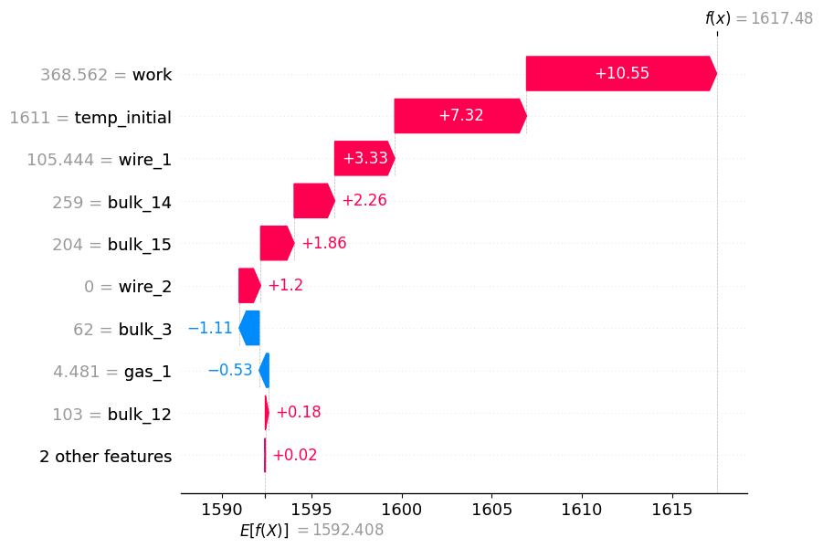

```python
shap.plots.waterfall(shap_values[0])
```

Можно увидеть как на примере первой записи в контрольной выборке считается предсказание, начиная с мат ожидания берутся значения признаков, и исходя из их относительного положения в распределении увеличивает или уменьшает значение.

### 4.6. Распределение параметров

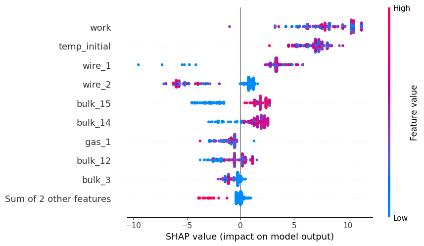

```python
shap.plots.beeswarm(shap_values)
```

Здесь можно увидеть как и насколько отдельные параметры влияют на предсказание. По оси X отражено математическое значение, в то время как цветом показано значение признака для предсказания от низкой(синей) до высокой(красной).

Примечательно что для многих признаков нет чёткой закономерности, что говорит о том что `shap` не удаётся в полной мере отразить логику модели.

**Выводы:**

Наиболее важные признаки - начальная температура и работа, примечателен среди добавок `wire_1`, который так же сильно влияет на результат.

## 5. Заключение

Задачей проекта является оценка температуры розлива, с целью использования модели для имитации процесса и последующего снижения затрат на электроэнергию.

Данные о процессе распределены между несколькими датафреймами, полученными от разных источников. Такая, подобная базе данных структура, и различные источники создают сложности из-за неполноты данных по некоторым партиям. Было бы полезно для дальнейших расчётов согласовать или вовсе объединить работу по сбору данных, если это возможно.

Говоря о содержании датафреймов, наиболее важными являются `temp` и `arc` описывающие замеры температуры и процесс нагрева. `arc` содержит качественные данные, хоть и в довольно странном формате требующем некоторых преобразований чтобы извлечь пользу. `temp` в свою очередь содержит данные в доступном и понятном формате но имеет огромное, около четверти всех партий, количество пропусков целевого признака. Необходимо выявить и устранить эту проблему, возможными причинами являются сбои оборудования, проблемы при переносе информации, или человеческая ошибка. Примечательно, что во многих случаях, для таких записей всё в порядке с начальной температурой, что может помочь выявить сбой.

Модель достигла необходимого уровня качества установленного заказчиком, в случае необходимости улучшить её было бы полезно иметь больше информации о нормах объёма добавок и газа, чтобы было легче отличать необычные партии от ошибок в данных не полагаясь на оду лишь статистику. Также было бы ценно знать что более ценно заказчику - способность предсказать результат как можно большего количество партий, или точность предсказания. Учитывая контекст предположено в процессе обработки было первое, но однозначная информация помогла бы лучше справится с задачей.

Если требуется модель значительно более высокого качества, возможно имеет смысл собрать данные о химическом составе сплавов. Косвенно изучая температуру мы изучаем именно его, и это бы дало возможность проводить более детальное исследование.

В дальнейших исследованиях рекомендую начинать обработку данных с температуры, т.к. данный датафрейм содержит один из наиболее важных показателей и целевой признак, собственно температуры в начале и конце технологического процесса. Это сократит затраты времени на обработку аномалий в партиях для которых нет важных деталей.

В качестве лучшей модели показал себя CatBoost - бустинговый алгоритм. Главными факторами в предсказании целевого признака стали температура, работа - выведенный на основе данных в `arc` синтетический признак - и, в меньшей степени, добавки `wire_1`.

## 6. Отчёт

### 6.1. Ответы на вопросы

1. Какие пункты плана были выполнены, а какие — нет (поясните, почему)?
   - Выполнены все пункты плана, некоторые, в частности, предобработка и анализ объединённой таблицы и подготовка к МО получились довольно короткими. Первый, потому что уже проведён детальный анализ признаков и условие составление таблицы по ключам во всех ДФ достаточно чистит данные. Второй, потому что таблица уже была в близком к оптимальному виде.
2. Какие трудности возникли и как вы их преодолели?
   - Самой большой трудностью я бы назвал принятие решений об обработки выбросов и аномалий, ввиду весьма скудной информации о деталях тех процесса, сложно понять где важная особенность, а где проблема с данными. Старался принимать решения на основе нескольких таблиц, оставлял не тронутыми спорный варианты во избежание потерь данных, жертвуя качеством модели в пользу способности обрабатывать как можно больше записей. Усложнил, по ошибке, для себя задачу оставив обработку `temp` в последнюю очередь. К тому времени как понял ошибку объём изменений который бы требовалось внести превысил объём оставшейся работы.
   - Подбор гиперпараметров без глубокого понимания работы моделей затруднителен. В целом опыт позволяет это делать лучше, но сложно сказать на сколько.
   - Из других затруднений выделю обработку `feature_importance_` и `shap`. Не занимался этим в предыдущих проектах, постарался использовать, посмотрел статью по `shap`, затрудняюсь оценить качество результата.
3. Какие ключевые шаги в решении задачи выделили?
   - Предобработка, типично, заняла больше всего усилий и времени. В частности:
     - Выделение `work` - выполнить не сложно, но важно было убедиться что всё сделано верно
     - Анализ связи ДФ, по сути структуры базы данных
     - Принятие решения по признакам и аномалиям которые стоит оставить
   - Важны конечно и собственно пункты плана, но это сам собой разумеется.

### 6.2. Список признаков, используемых для обучения лучшей модели и описание их предобработки.

```python
list(features.columns)
```

```
['temp_initial',
 'work',
 'gas_1',
 'bulk_3',
 'bulk_4',
 'bulk_11',
 'bulk_12',
 'bulk_14',
 'bulk_15',
 'wire_1',
 'wire_2']
```

Начальная температура была взята с помощью анализа дубликатов `key` ДФ `temp`, после того как убедился, что они по порядку.

Работа это квинтэссенция `arc`, данные качественные, потребовали минимум предобработки, но достаточно детального синтеза чтобы получить её.

`gas`, `wire`, `bulk` Все обрабатывались детально, где столкнулся с вышеописанной проблемой принятия решений об аномальных значениях. В добавок, кроме газа, было принято решение отбрасывать столбцы с очень маленьким количеством записей для ускорения работы модели, что позволяет более детально подбирать и эксперементировать с гиперпараметрами, и избежания искажений предсказаний из-за статистически недостаточных данных.

После этого ряд признаков `bulk` был отброшен т.к. несли низкую ценность и имели сравнительно высокую корреляцию.

Все признаки также были подчищены в результате объединения таблиц, в особенности ввиду значительного количества возможных аномалий, для которых оказывалось, что нет ЦП.

### 6.3. Гиперпараметры лучшей модели, включая random_state (если имеется у модели).

```python
clf_cat_boost.best_estimator_.get_params()
```

```
{'loss_function': 'MAE',
 'verbose': 0,
 'random_state': 28122023,
 'bootstrap_type': 'Bernoulli',
 'l2_leaf_reg': 3.5,
 'learning_rate': 0.01}
```

Примечательно, что в документации катбуст `loss_function` и `objective` описаны как `alias`, но при выводе в отчёте (в рамках проекта выводил параметры GridSearch) оказались разными(`RMSE`/`MAE`). Пришлось возвращаться править.

### 6.4. Что рекомендуете для улучшения модели, решения

На самом деле достаточно много идей о том как можно улучшить проект, в том числе переписав весь раздел предобработки отдельных ДФ в более разумном порядке, начиная с `temp`.

Возможно стоит более жёстко подойти к выявленным аномалиям, отбрасывая их - попытка восстановить не зная детали тех процесса видится еще менее уместной в большинстве случаев - для улучшения качества модели, жертвуя количеством обрабатываемых данных.

Возможно стоит вместо того чтобы отбрасывать малочисленные `wire`, `bulk` либо оставить их, либо сгруппировать.

Было бы идеально получить дополнительную информацию от заказчика, чтобы устранить неопределённости.